# Ikrame_ADAM12_TAK1

#**Les librairies :** ___________________

```r
library(ggplot2)
library(DESeq2)
library(plotly)
library(ggrepel)
library(RColorBrewer)
library(heatmap3)
library(cluster)
library(factoextra)
library(magrittr)
library(dendextend)
library("devtools")
source_url("https://raw.githubusercontent.com/obigriffith/biostar-tutorials/master/Heatmaps/heatmap.3.R")
```

[output not shown]

#**Les données :** ______________

```r
dds_tableTOT_CRC=read.table(file="C:/Users/Mathieu V/Desktop/These_Marthe/Projet_Bioinfo/171220_TCGA_COAD/dds_tableTOT_CRC.txt", header=TRUE, sep="\t")
clab_CRC=read.table(file="C:/Users/Mathieu V/Desktop/These_Marthe/Projet_Bioinfo/171220_TCGA_COAD/clab_CRC.txt", header=TRUE, sep="\t")

dds_tableTOT_lung=read.table(file="C:/Users/Mathieu V/Desktop/These_Marthe/Projet_Bioinfo/180216_TCGA_LUNG/dds_tableTOT_Lung.txt", header=TRUE, sep="\t")
clab_lung=read.table(file="C:/Users/Mathieu V/Desktop/These_Marthe/Projet_Bioinfo/180216_TCGA_LUNG/labels_lung.txt", header=TRUE, sep="\t")

dds_tableTOT_breast=read.table(file="C:/Users/Mathieu V/Desktop/These_Marthe/Projet_Bioinfo/180301_TCGA_BREAST/dds_tableTOT_Breast.txt", header=TRUE, sep="\t")
clab_breast=read.table(file="C:/Users/Mathieu V/Desktop/These_Marthe/Projet_Bioinfo/180301_TCGA_BREAST/labels_Breast.txt", header=TRUE, sep="\t")

Trad=read.table(file="C:/Users/Mathieu V/Desktop/These_Marthe/Projet_Bioinfo/171220_TCGA_COAD/Trad.txt", header=TRUE, sep="\t")

load("C:/Users/Mathieu V/Desktop/These_Marthe/Projet_Bioinfo/180313_TCGA_Ikrame/Ikrame_ADAM12_TAK1.RData")
```

Les sous-groupes d’expression de ADAM12 : ________________________________________

```r
rownames(dds_tableTOT_CRC)=make.names(Trad$Symbol, unique=TRUE)
rownames(dds_tableTOT_lung)=make.names(Trad$Symbol, unique=TRUE)
rownames(dds_tableTOT_breast)=make.names(Trad$Symbol, unique=TRUE)

#Les premières et dernières lignes contiennent les annotations ENSG et HUGO, on les enlève (pas besoin ici, UGO en rownames)
dds_tableTOT_CRC=dds_tableTOT_CRC[,-c(1,dim(dds_tableTOT_CRC)[2])]
dds_tableTOT_lung=dds_tableTOT_lung[,-c(1)]
dds_tableTOT_breast=dds_tableTOT_breast[,-c(1,dim(dds_tableTOT_breast)[2])]

#on isole les tissus normaux et les tumeurs, on veut les premiers et dernier décile d'expression de ADAM12 dans les tumeurs spécifiquement
dds_tissunorm_CRC=dds_tableTOT_CRC[,c(which(as.data.frame(clab_CRC)$Type=="hotpink"))]
dds_tumor_CRC=dds_tableTOT_CRC[,c(which(as.data.frame(clab_CRC)$Type=="black"))]

dds_tissunorm_lung=dds_tableTOT_lung[,c(which(clab_lung$Type=="Solid Tissue Normal"))]
dds_tumor_lung=dds_tableTOT_lung[,c(which(clab_lung$Type=="Primary Tumor"))]

dds_tissunorm_breast=dds_tableTOT_breast[,c(which(clab_breast$Type=="Solid Tissue Normal"))]
dds_tumor_breast=dds_tableTOT_breast[,c(which(clab_breast$Type=="Primary Tumor"))]




#on fait un vecteur ADAM avec seulement les valeurs d'expression d'ADAM12; et en titre les échantillons correspondants
ADAM_NT_CRC=c(as.numeric(dds_tissunorm_CRC[which(rownames(dds_tissunorm_CRC)=="ADAM12"),]))
names(ADAM_NT_CRC)=colnames(dds_tissunorm_CRC[,])
ADAM_tumor_CRC=c(as.numeric(dds_tumor_CRC[which(rownames(dds_tumor_CRC)=="ADAM12"),]))
names(ADAM_tumor_CRC)=colnames(dds_tumor_CRC[,])

ADAM_NT_lung=c(as.numeric(dds_tissunorm_lung[which(rownames(dds_tissunorm_lung)=="ADAM12"),]))
names(ADAM_NT_lung)=colnames(dds_tissunorm_lung[,])
ADAM_tumor_lung=c(as.numeric(dds_tumor_lung[which(rownames(dds_tumor_lung)=="ADAM12"),]))
names(ADAM_tumor_lung)=colnames(dds_tumor_lung[,])

ADAM_NT_breast=c(as.numeric(dds_tissunorm_breast[which(rownames(dds_tissunorm_breast)=="ADAM12"),]))
names(ADAM_NT_breast)=colnames(dds_tissunorm_breast[,])
ADAM_tumor_breast=c(as.numeric(dds_tumor_breast[which(rownames(dds_tumor_breast)=="ADAM12"),]))
names(ADAM_tumor_breast)=colnames(dds_tumor_breast[,])

#On prend les noms des échantillons du premier et du dernier décile
high_ADAM_CRC=names(which(ADAM_tumor_CRC>quantile(ADAM_tumor_CRC,0.9)))
low_ADAM_CRC=names(which(ADAM_tumor_CRC<=quantile(ADAM_tumor_CRC,0.1)))
NT_CRC=names(ADAM_NT_CRC)

high_ADAM_lung=names(which(ADAM_tumor_lung>quantile(ADAM_tumor_lung,0.9)))
low_ADAM_lung=names(which(ADAM_tumor_lung<=quantile(ADAM_tumor_lung,0.1)))
NT_lung=names(ADAM_NT_lung)

high_ADAM_breast=names(which(ADAM_tumor_breast>quantile(ADAM_tumor_breast,0.9)))
low_ADAM_breast=names(which(ADAM_tumor_breast<=quantile(ADAM_tumor_breast,0.1)))
NT_breast=names(ADAM_NT_breast)


c(length(high_ADAM_CRC),length(low_ADAM_CRC),length(high_ADAM_lung),length(low_ADAM_lung),length(high_ADAM_breast),length(low_ADAM_breast) )
```

On voudrait comparer l’expression d’ADAM12 entre NT et tumor dans le sein, pour justifier le modele d’Ikrame ADAM12 NT / Tum ————

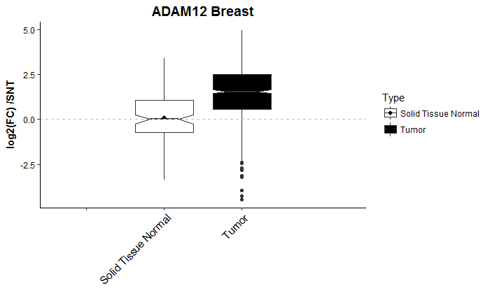

## Test stats

```r
data=data.frame(stack(dds_tableTOT_breast[which(rownames(dds_tableTOT_breast)=="ADAM12"),]/median(ADAM_NT_breast)),
                       Type,Stage,ClassTum )
head(data)
```

|  | values | ind | Type | Stage | ClassTum |
| --- | --- | --- | --- | --- | --- |
| 1 | 0.7744331 | X1AB92ADA.637E.4A42.A39A.70CEEEA41AE3 | Tumor | Stage I | hormono-dependant |
| 2 | 0.3386261 | DA98A67C.F11F.41D3.8223.1161EBFF8B58 | Tumor | Stage I | hormono-dependant |
| 3 | 10.0434907 | X06CCFD0F.7FB8.471E.B823.C7876582D6FC | Tumor | Stage II | HER2-amplified |
| 4 | 1.9630363 | A33B2F42.6EC6.4FB2.8BE5.542407A0382E | Tumor | Stage II | hormono-dependant |
| 5 | 13.1740456 | CC4C52A7.57D4.4959.ABFB.8ED3B1BA4DED | Tumor | Stage I | hormono-dependant |
| 6 | 8.8603869 | D021A258.8713.4383.9DCA.45E2F54A0411 | Tumor | Stage III | hormono-dependant |

```r
summary(aov(values ~ Type,data))
```

```
              Df Sum Sq Mean Sq F value   Pr(>F)
Type           1    603   602.9   48.65 4.96e-12 ***
Residuals   1244  15416    12.4
---
Signif. codes:  0 *** 0.001 ** 0.01 * 0.05 . 0.1   1
```

```r
#install.packages('PMCMRplus')
library(PMCMRplus)
#?tukeyTest
summary(tukeyTest(values ~ Type,data))
```

```
    Pairwise comparisons using Tukey's test

data: values by Type
alternative hypothesis: two.sided
P value adjustment method: single-step
H0
```

```
                                 q value   Pr(>|q|)
Tumor - Solid Tissue Normal == 0   9.864 4.2933e-12 ***
```

[output not shown]

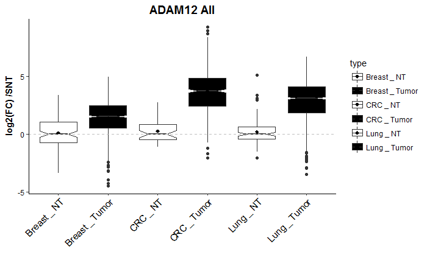

```r
total_type=rep(NA, length(c(clab_breast$Type,clab_CRC$Type,clab_lung$Type)))
total_type[which(is.element(clab_breast$Type, c("Solid Tissue Normal")))]="Breast _ NT"
total_type[c(which(is.element(clab_breast$Type, c("Metastatic", "Primary Tumor"))))]="Breast _ Tumor"
total_type[c(length(clab_breast$Type)+which(is.element(clab_CRC$Type, c("hotpink"))))]="CRC _ NT"
total_type[c(length(clab_breast$Type)+which(is.element(clab_CRC$Type, c("grey50", "black"))))]="CRC _ Tumor"
total_type[c(length(clab_breast$Type)+length(clab_CRC$Type)+which(is.element(clab_lung$Type, c("Solid Tissue Normal"))))]="Lung _ NT"
total_type[c(length(clab_breast$Type)+length(clab_CRC$Type)+which(is.element(clab_lung$Type, c("Recurrent Tumor", "Primary Tumor"))))]="Lung _ Tumor"
P1=ggplot(data=data.frame(values=c(t(dds_tableTOT_breast[which(rownames(dds_tableTOT_breast)=="ADAM12"),]/median(ADAM_NT_breast)),
                        t(dds_tableTOT_CRC[which(rownames(dds_tableTOT_CRC)=="ADAM12"),]/median(ADAM_NT_CRC)),
                         t(dds_tableTOT_lung[which(rownames(dds_tableTOT_lung)=="ADAM12"),]/median(ADAM_NT_lung))),
                type=total_type),
       aes(x=type, y=log2(values), fill=type))+
    geom_boxplot(position = position_dodge(0.9), notch=TRUE)+
  stat_summary(fun.y=mean, geom="point", shape=18,
                size=2, color="black",position = position_dodge(0.9))+
            geom_hline(yintercept=0, linetype="dashed", color = "grey")+
  labs(title="ADAM12 All", y="log2(FC) /SNT",x=" ",cex=10)+
  theme_classic()+
  theme(plot.title = element_text(size = 14, face = "bold",hjust=0.5),
              text=element_text(),
              axis.title = element_text(face="bold"),
              axis.text.x=element_text(angle=45, hjust=1,colour="black", size = 11),
              axis.text.y=element_text(colour="black", size = 9))+
#  scale_x_discrete(limits=c("","Solid Tissue Normal","Tumor",""))+
  scale_fill_manual(values=c("white","black","white", "black", "white", "black"))
P1
```

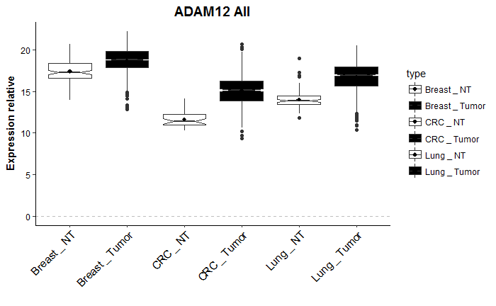

```r
P=ggplot(data=data.frame(values=c(t(dds_tableTOT_breast[which(rownames(dds_tableTOT_breast)=="ADAM12"),]),
                        t(dds_tableTOT_CRC[which(rownames(dds_tableTOT_CRC)=="ADAM12"),]),
                         t(dds_tableTOT_lung[which(rownames(dds_tableTOT_lung)=="ADAM12"),])),
                type=total_type),
       aes(x=type, y=log2(values), fill=type))+
    geom_boxplot(position = position_dodge(0.9), notch=TRUE)+
  stat_summary(fun.y=mean, geom="point", shape=18,
                size=2, color="black",position = position_dodge(0.9))+
            geom_hline(yintercept=0, linetype="dashed", color = "grey")+
  labs(title="ADAM12 All", y="Expression relative",x=" ",cex=10)+
  theme_classic()+
  theme(plot.title = element_text(size = 14, face = "bold",hjust=0.5),
              text=element_text(),
              axis.title = element_text(face="bold"),
              axis.text.x=element_text(angle=45, hjust=1,colour="black", size = 11),
              axis.text.y=element_text(colour="black", size = 9))+
#  scale_x_discrete(limits=c("","Solid Tissue Normal","Tumor",""))+
  scale_fill_manual(values=c("white","black","white", "black", "white", "black"))
P
```

```r
Stage=c(coldata_rse_breast$cgc_case_pathologic_stage)
levels(as.factor(Stage))
```

```
 [1] "Stage I"    "Stage IA"   "Stage IB"   "Stage II"   "Stage IIA"  "Stage IIB"
 [7] "Stage III"  "Stage IIIA" "Stage IIIB" "Stage IIIC" "Stage IV"   "Stage Tis"
[13] "Stage X"
```

```r
length(Stage)
```

```
[1] 1246
```

```r
Stage[which(is.element(Stage, c("Stage I","Stage IA","Stage IB"))==TRUE)]="Stage I"
Stage[which(is.element(Stage, c("Stage II","Stage IIA","Stage IIB"))==TRUE)]="Stage II"
Stage[which(is.element(Stage, c( "Stage III"  ,"Stage IIIA", "Stage IIIB", "Stage IIIC"))==T)]="Stage III"
Stage[which(is.element(Stage, c( "Stage IV"))==T)]="Stage IV"
Stage[which(is.element(Stage, c( "Stage Tis" , "Stage X"))==T)]=NA
Stage[which(coldata_rse_breast$gdc_cases.samples.sample_type=="Solid Tissue Normal")]="Normal"
Stage=as.factor(as.character(Stage))
summary(Stage)
```

```
   Normal   Stage I  Stage II Stage III  Stage IV      NA's
      112       186       646       252        20        30
```

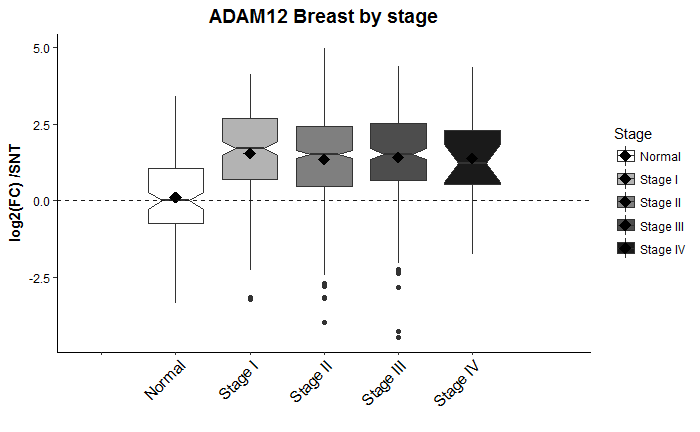

```r
P2=ggplot(data=data.frame(stack(dds_tableTOT_breast[which(rownames(dds_tableTOT_breast)=="ADAM12"),]/median(ADAM_NT_breast)),
                       Type,Stage,ClassTum ),
       aes(x=Stage, y=log2(values), fill=Stage))+
    geom_boxplot(position = position_dodge(0.9), notch=TRUE)+
  stat_summary(fun.y=mean, geom="point", shape=18,
                size=4, color="black",position = position_dodge(0.9))+
            geom_hline(yintercept=0, linetype="dashed", color = "grey10")+
  labs(title="ADAM12 Breast by stage", y="log2(FC) /SNT",x=" ",cex=10)+
  theme_classic()+
  theme(plot.title = element_text(size = 14, face = "bold",hjust=0.5),
              text=element_text(),
              axis.title = element_text(face="bold"),
              axis.text.x=element_text(angle=45, hjust=1,colour="black", size = 11),
              axis.text.y=element_text(colour="black", size = 9))+
  scale_x_discrete(limits=c("","Normal","Stage I","Stage II", "Stage III", "Stage IV", ""))+
  scale_fill_manual(values=c("white","grey70","grey50", "grey30", "grey10", "white"))
P2
```

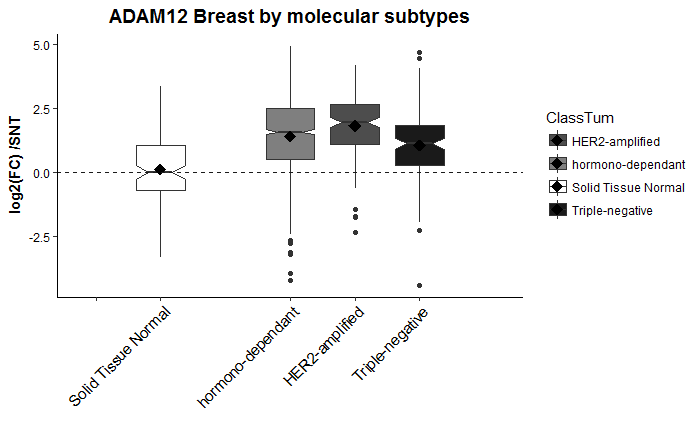

[figure not shown]

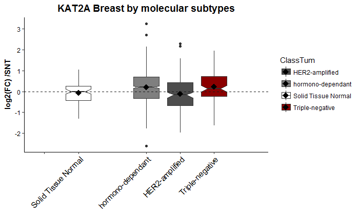

```r
KAT2A_NT_breast=c(as.numeric(dds_tissunorm_breast[which(rownames(dds_tissunorm_breast)=="KAT2A"),]))
ggplot(data=data.frame(stack(dds_tableTOT_breast[which(rownames(dds_tableTOT_breast)=="KAT2A"),]/median(KAT2A_NT_breast)),
                       Type,Stage,ClassTum ),
       aes(x=ClassTum, y=log2(values), fill=ClassTum))+
    geom_boxplot(position = position_dodge(0.9), notch=TRUE)+
  stat_summary(fun.y=mean, geom="point", shape=18,
                size=4, color="black",position = position_dodge(0.9))+
            geom_hline(yintercept=0, linetype="dashed", color = "grey10")+
  labs(title="KAT2A Breast by molecular subtypes", y="log2(FC) /SNT",x=" ",cex=10)+
  theme_classic()+
  theme(plot.title = element_text(size = 14, face = "bold",hjust=0.5),
              text=element_text(),
              axis.title = element_text(face="bold"),
              axis.text.x=element_text(angle=45, hjust=1,colour="black", size = 11),
              axis.text.y=element_text(colour="black", size = 9))+
  scale_x_discrete(limits=c("","Solid Tissue Normal","","hormono-dependant","HER2-amplified", "Triple-negative", ""))+
  scale_fill_manual(values=c( "grey30","grey50","white", "red4"))
```

#JPapier

```r
plotX=ggplot()+ theme_classic() #plot espaceur

grid.arrange(P1, plotX, P2, P3,
             ncol=2, nrow=2,
             widths=c(2,2), heights=c(4,4)
             )
```

#Courbe de survie selon expression ADAM12

```r
coldata_rse_breast=colData(rse_gene)
dim(coldata_rse_breast)
```

```
[1] 1246  864
```

```r
dim(dds_tableTOT_breast)
```

```
[1] 58037  1246
```

```r
Type_sample=coldata_rse_breast$gdc_cases.samples.sample_type
years_to_death=(coldata_rse_breast$gdc_cases.diagnoses.days_to_death)/(365)
years_to_last_follow_up=coldata_rse_breast$gdc_cases.diagnoses.days_to_last_follow_up/(365)
New_tumor_event=(coldata_rse_breast$cgc_case_new_tumor_event_after_initial_treatment)
head(data.frame(years_to_death, years_to_last_follow_up, New_tumor_event))
```

|  | years_to_death | years_to_last_follow_up | New_tumor_event |
| --- | --- | --- | --- |
| 1 | NA | 0.92328767 | NA |
| 2 | NA | 0.70958904 | NA |
| 3 | NA | 8.49863014 | NA |
| 4 | NA | 0.01369863 | NA |
| 5 | NA | 2.07945205 | NO |
| 6 | NA | 2.61369863 | NA |

```r
#survie gloable : le premier évenement est la mort
Suivi_Mort=years_to_last_follow_up
Suivi_Mort[which(is.na(years_to_death)==FALSE)]=years_to_death[which(is.na(years_to_death)==FALSE)]
status_mort=rep(NA, length(years_to_death))
status_mort[which(is.na(years_to_death)==TRUE)]=0
status_mort[which(is.na(years_to_death)==FALSE)]=1
#survie sans progression : le premier évenement est la mort ou la rechute
Suivi_progression=years_to_last_follow_up
#on prend la date du dernier suivi, et si pas d'info on prend la date de la mort (généralement c'est exclusif)
Suivi_progression[which(is.na(years_to_last_follow_up)==TRUE)]=years_to_death[which(is.na(years_to_last_follow_up)==TRUE)]
status_recidive=rep(NA, length(New_tumor_event))
status_recidive[which(is.na(New_tumor_event)==TRUE)]=0
status_recidive[which(is.na(New_tumor_event)==FALSE)]=1 #on met des 1 si la personne rechute
status_recidive[which(is.na(years_to_death)==FALSE)]=1 #et des 1 si la personne récidive
head(cbind(Suivi_progression, status_recidive, Suivi_Mort, status_mort),10)
```

```
      Suivi_progression status_recidive Suivi_Mort status_mort
 [1,]        0.92328767               0 0.92328767           0
 [2,]        0.70958904               0 0.70958904           0
 [3,]        8.49863014               0 8.49863014           0
 [4,]        0.01369863               0 0.01369863           0
 [5,]        2.07945205               1 2.07945205           0
 [6,]        2.61369863               0 2.61369863           0
 [7,]        2.61369863               0 2.61369863           0
 [8,]        2.61369863               0 2.61369863           0
 [9,]        0.83287671               0 0.83287671           0
[10,]        1.37808219               0 1.37808219           0
```

```r
library(survival)
library(survminer)
A=dds_tableTOT_breast[which(rownames(dds_tableTOT_breast)=="MAP3K7"),]
Quant2=rep(NA, dim(dds_tableTOT_breast)[2])
Quant2[which(A>=quantile(A, na.rm=T, 0.5))]="High"
#Quant2[which(A<quantile(A, na.rm=T, 0.75))]="Int"
Quant2[which(A<=quantile(A, na.rm=T, 0.5))]="Low"
mydata=data.frame(time=Suivi_progression[which(Type_sample!="Solid Tissue Normal"&ClassTum=="Triple-negative")],
                  status=status_recidive[which(Type_sample!="Solid Tissue Normal"&ClassTum=="Triple-negative")],
                  Decile=Quant2[which(Type_sample!="Solid Tissue Normal"&ClassTum=="Triple-negative")])
# List of ggsurvplots
splots <- list()
fit_recid=survfit(Surv(time,status)~Decile,data=mydata)
splots[[1]] <- ggsurvplot(fit_recid, data = mydata,
   legend = "bottom",
   legend.title = "Breast",
   legend.labs = c("High", "Low"),
   palette = c("red4", "green4"),
   font.x = c(10),
   font.y = c(10),
   main="Survie sans récidive TSP Nat Com",
   pval = TRUE,
              risk.table = TRUE,   surv.median.line=c("v"),
              tables.y.text = FALSE,
              ggtheme = theme_classic())
#2e plot = survie globale
mydata2=data.frame(time=Suivi_Mort[which(Type_sample!="Solid Tissue Normal"&ClassTum=="Triple-negative")],
                  status=status_mort[which(Type_sample!="Solid Tissue Normal"&ClassTum=="Triple-negative")],
                  Decile=Quant2[which(Type_sample!="Solid Tissue Normal"&ClassTum=="Triple-negative")])
summary(as.factor(mydata$status))
```

```
 0  1
83 37
```

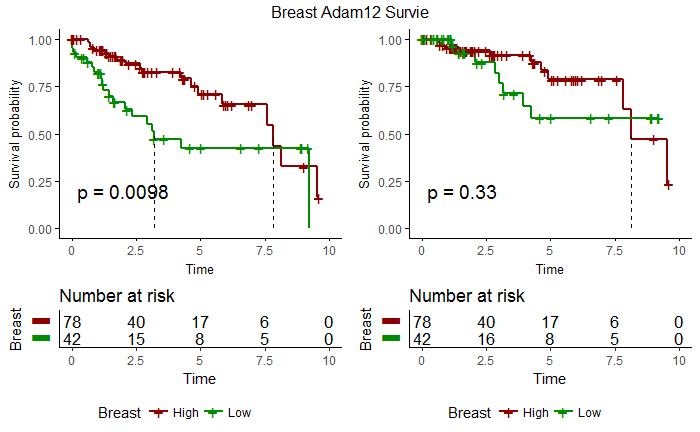

```r
fit_mort=survfit(Surv(time,status)~Decile,data=mydata2)
splots[[2]] <- ggsurvplot(fit_mort, data = mydata2,
   legend = "bottom",
   legend.title = "Breast",
  legend.labs = c("High", "Low"),
   palette = c("red4","green4"),
   font.x = c(10),
   font.y = c(10),
   main="Survie sans récidive TSP Nat Com",
   pval = TRUE,
              risk.table = TRUE,   surv.median.line=c("v"),
              tables.y.text = FALSE,
              ggtheme = theme_classic())

# Arrange multiple ggsurvplots and print the output
arrange_ggsurvplots(splots, print = TRUE, title="Breast Adam12 Survie",
  ncol = 2, nrow = 1, risk.table.height = 0.3)
```

```r
B=ClassTum
A=dds_tableTOT_breast[which(rownames(dds_tableTOT_breast)=="ADAM12"),]
Quant2=rep(NA, dim(dds_tableTOT_breast)[2])
Quant2[which(A>=quantile(A, na.rm=T, 0.9))]="High"
#Quant2[which(A<quantile(A, na.rm=T, 0.75))]="Int"
Quant2[which(A<=quantile(A, na.rm=T, 0.1))]="Low"
mydata=data.frame(time=Suivi_progression[which(Type_sample!="Solid Tissue Normal")],
                  status=status_recidive[which(Type_sample!="Solid Tissue Normal")],
                  Decile=Quant2[which(Type_sample!="Solid Tissue Normal")])
# List of ggsurvplots
splots <- list()
fit_recid=survfit(Surv(time,status)~Decile,data=mydata)
splots[[1]] <- ggsurvplot(fit_recid, data = mydata,
   legend = "bottom",
   legend.title = "Breast",
   legend.labs = c("High", "Low"),
   palette = c("red4", "green4"),
   font.x = c(10),
   font.y = c(10),
   main="Survie sans récidive TSP Nat Com",
   pval = TRUE,
              risk.table = TRUE,   surv.median.line=c("v"),
              tables.y.text = FALSE,
              ggtheme = theme_classic())
#2e plot = survie globale
mydata2=data.frame(time=Suivi_Mort[which(Type_sample!="Solid Tissue Normal")],
                  status=status_mort[which(Type_sample!="Solid Tissue Normal")],
                  Decile=Quant2[which(Type_sample!="Solid Tissue Normal")])
summary(as.factor(mydata$status))
```

```
  0   1
805 329
```

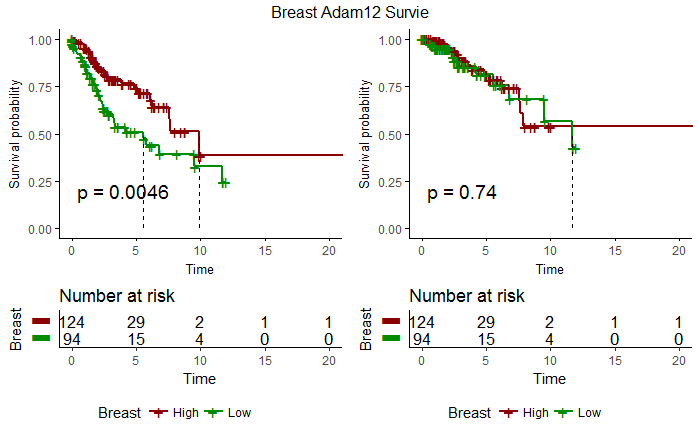

```r
fit_mort=survfit(Surv(time,status)~Decile,data=mydata2)
splots[[2]] <- ggsurvplot(fit_mort, data = mydata2,
   legend = "bottom",
   legend.title = "Breast",
  legend.labs = c("High", "Low"),
   palette = c("red4","green4"),
   font.x = c(10),
   font.y = c(10),
   main="Survie sans récidive TSP Nat Com",
   pval = TRUE,
              risk.table = TRUE,   surv.median.line=c("v"),
              tables.y.text = FALSE,
              ggtheme = theme_classic())

# Arrange multiple ggsurvplots and print the output
arrange_ggsurvplots(splots, print = TRUE, title="Breast Adam12 Survie",
  ncol = 2, nrow = 1, risk.table.height = 0.3)
```

#Modèles de Cox

```r
A=dds_tableTOT_breast[which(rownames(dds_tableTOT_breast)=="ADAM12"),]

ADAM12=rep(NA, dim(dds_tableTOT_breast)[1])
ADAM12[which(A>=quantile(A, na.rm=T, 0.9))]="High"
ADAM12[which(A<quantile(A, na.rm=T, 0.9))]="Int"
ADAM12[which(A<=quantile(A, na.rm=T, 0.1))]="Low"
ADAM12=as.factor(ADAM12)
ADAM12=factor(ADAM12, levels(ADAM12)[c(2,1,3)]) #pour réordonner les niveaux des facteurs

#on enlève les valeurs normales
ADAM12[which(Type_sample=="Solid Tissue Normal")]=NA

Age=c(coldata_rse_breast$xml_age_at_initial_pathologic_diagnosis)
Age[which(coldata_rse_breast$xml_age_at_initial_pathologic_diagnosis<=75)]="50-75"
Age[which(coldata_rse_breast$xml_age_at_initial_pathologic_diagnosis<=55)]="<=50"
Age[which(coldata_rse_breast$xml_age_at_initial_pathologic_diagnosis>75)]=">75"
Age=as.factor(Age)
Age=factor(Age, levels(Age)[c(3,1:2)])

Stage=c(coldata_rse_breast$cgc_case_pathologic_stage)
levels(as.factor(Stage))
length(Stage)
Stage[which(is.element(Stage, c("Stage I","Stage IA","Stage IB","Stage II","Stage IIA","Stage IIB"))==TRUE)]="Stage I-II"
Stage[which(is.element(Stage, c( "Stage III"  ,"Stage IIIA", "Stage IIIB", "Stage IIIC", "Stage IV"))==T)]="Stage III-IV"
Stage[which(is.element(Stage, c( "Stage Tis" , "Stage X"))==T)]=NA
head(Stage)
Stage=as.factor(as.character(Stage))
summary(as.factor(as.character(Stage)))

ClassTum=rep(NA, length(clab_breast$Stage))
ClassTum[which(clab_breast$ER=="Negative"&clab_breast$PR=="Negative"&clab_breast$HER2=="Negative")]="Triple negative"
ClassTum[which(clab_breast$ER=="Positive")]="HR"
ClassTum[which(clab_breast$PR=="Positive")]="HR"
ClassTum[which(clab_breast$HER2=="Positive")]="HER2"
ClassTum[which(clab_breast$HER2=="Equivocal")]=NA
ClassTum=as.factor(ClassTum)
ClassTum=factor(ClassTum, levels(ClassTum)[c(1,2,3)]) #pour réordonner les niveaux des facteurs


mydata=data.frame(time=Suivi_progression[which(Type_sample!="Solid Tissue Normal")],
                  status=status_recidive[which(Type_sample!="Solid Tissue Normal")],
                  Stage=as.factor(Stage[which(Type_sample!="Solid Tissue Normal")]),
                  ADAM12=ADAM12[which(Type_sample!="Solid Tissue Normal")],
                  Age=Age[which(Type_sample!="Solid Tissue Normal")],
                  ClassTum=ClassTum[which(Type_sample!="Solid Tissue Normal")])
res.cox.r=coxph( Surv(time, status) ~ ADAM12 + Stage + Age +ClassTum ,
                data = mydata )
res.cox.r
```

Pour tracer le forest plot

```r
plot=ggforest(res.cox.r, main="Hazard Ratio recidive")
plot=plot+theme_classic()+
 theme(plot.title = element_text(size = 14, face = "bold",hjust = 0.5),
              text=element_text(),
              axis.title = element_text(face="bold"),
              axis.text.x=element_text(angle=45, hjust=1,colour="black", size = 11),
              axis.text.y=element_text(colour="black", size = 9))
print(plot)
```

```r
#On récupere les labels des échantillons sélectionnés, on ajoute une colonne contenant le groupe ADAM, et une colonne contenant le type de tissu
clab_ADAM_CRC=cbind(clab_CRC[c(c(which(is.element(colnames(dds_tableTOT_CRC), NT_CRC)==TRUE)),
                              c(which(is.element(colnames(dds_tableTOT_CRC), low_ADAM_CRC)==TRUE)),
                    c(which(is.element(colnames(dds_tableTOT_CRC), high_ADAM_CRC)==TRUE))),],
                    Decile=c(rep("NT",length(NT_CRC)),
                         rep("tumor_low_ADAM",length(low_ADAM_CRC)),
                         rep("tumor_high_ADAM",length(low_ADAM_CRC))),
                    Tissue=c(rep("CRC", sum(length(NT_CRC),length(low_ADAM_CRC),length(low_ADAM_CRC)))))

clab_ADAM_lung=cbind(clab_lung[c(c(which(is.element(colnames(dds_tableTOT_lung), NT_lung)==TRUE)),
                              c(which(is.element(colnames(dds_tableTOT_lung), low_ADAM_lung)==TRUE)),
                    c(which(is.element(colnames(dds_tableTOT_lung), high_ADAM_lung)==TRUE))),],
                    Decile=c(rep("NT",length(NT_lung)),
                         rep("tumor_low_ADAM",length(low_ADAM_lung)),
                         rep("tumor_high_ADAM",length(low_ADAM_lung))),
                    Tissue=c(rep("lung", sum(length(NT_lung),length(low_ADAM_lung),length(low_ADAM_lung)))))

clab_ADAM_breast=cbind(clab_breast[c(c(which(is.element(colnames(dds_tableTOT_breast), NT_breast)==TRUE)),
                              c(which(is.element(colnames(dds_tableTOT_breast), low_ADAM_breast)==TRUE)),
                    c(which(is.element(colnames(dds_tableTOT_breast), high_ADAM_breast)==TRUE))),],
                    Decile=c(rep("NT",length(NT_breast)),
                         rep("tumor_low_ADAM",length(low_ADAM_breast)),
                         rep("tumor_high_ADAM",length(low_ADAM_breast))),
                    Tissue=c(rep("breast", sum(length(NT_breast),length(low_ADAM_breast),length(low_ADAM_breast)))))

clab_ADAM_tot=cbind(Decile=c(as.character(clab_ADAM_CRC$Decile),as.character(clab_ADAM_lung$Decile),as.character(clab_ADAM_breast$Decile)),
                    Tissue=c(as.character(clab_ADAM_CRC$Tissue),as.character(clab_ADAM_lung$Tissue),as.character(clab_ADAM_breast$Tissue)))
```

```r
#on construit les subsets de dds_tot avec ces samples là
ComparADAM_ddsTOT_CRC=dds_tableTOT_CRC[,c(which(is.element(colnames(dds_tableTOT_CRC), NT_CRC)==TRUE),
                                which(is.element(colnames(dds_tableTOT_CRC), low_ADAM_CRC)==TRUE),
                                which(is.element(colnames(dds_tableTOT_CRC), high_ADAM_CRC)==TRUE))]
ComparADAM_ddsTOT_NT_CRC=dds_tableTOT_CRC[,c(which(is.element(colnames(dds_tableTOT_CRC), NT_CRC)==TRUE))]

ComparADAM_ddsTOT_lung=dds_tableTOT_lung[,c(which(is.element(colnames(dds_tableTOT_lung), NT_lung)==TRUE),
                                which(is.element(colnames(dds_tableTOT_lung), low_ADAM_lung)==TRUE),
                                which(is.element(colnames(dds_tableTOT_lung), high_ADAM_lung)==TRUE))]
ComparADAM_ddsTOT_NT_lung=dds_tableTOT_lung[,c(which(is.element(colnames(dds_tableTOT_lung), NT_lung)==TRUE))]

ComparADAM_ddsTOT_breast=dds_tableTOT_breast[,c(which(is.element(colnames(dds_tableTOT_breast), NT_breast)==TRUE),
                                which(is.element(colnames(dds_tableTOT_breast), low_ADAM_breast)==TRUE),
                                which(is.element(colnames(dds_tableTOT_breast), high_ADAM_breast)==TRUE))]
ComparADAM_ddsTOT_NT_breast=dds_tableTOT_breast[,c(which(is.element(colnames(dds_tableTOT_breast), NT_breast)==TRUE))]

ComparADAM_ddsTOT_total=cbind(ComparADAM_ddsTOT_CRC,ComparADAM_ddsTOT_lung,ComparADAM_ddsTOT_breast)
```

#Activation TAK1 à partir des gènes cibles d’oli*

On veut normaliser les gènes cibles de TAK1 par rapport à leur niveau d’expression basal dans les tissus normaux correspondants

Le vecteur contenant le nom des gènes TAK1 est SignatureTAK1

## Construction subset et calcul signatire TAK1

```r
rm(SignatureTAK1)
SignatureTAK1=read.table(file="C:/Users/Mathieu V/Desktop/These_Marthe/Projet_Bioinfo/180310_Signature_TAK1/SIgnatureTAK1pos.txt", header=F, sep="\t")
#SignatureTAK1=read.table(file="C:/Users/Mathieu V/Desktop/These_Marthe/Projet_Bioinfo/180310_Signature_TAK1/SIgnatureTAK1neg.txt", header=F, sep="\t")

head(SignatureTAK1)
```

|  | V1 |
| --- | --- |
| 1 | TSPAN2 |
| 2 | MURC |
| 3 | NEDD9 |
| 4 | RASL11B |
| 5 | HBEGF |
| 6 | FZD8 |

```r
library("psych")
subADAM_TAK1_b=ComparADAM_ddsTOT_breast[which(is.element(rownames(ComparADAM_ddsTOT_breast), SignatureTAK1$V1)==TRUE),]
subADAM_TAK1_l=ComparADAM_ddsTOT_lung[which(is.element(rownames(ComparADAM_ddsTOT_breast), SignatureTAK1$V1)==TRUE),]
subADAM_TAK1_c=ComparADAM_ddsTOT_CRC[which(is.element(rownames(ComparADAM_ddsTOT_breast), SignatureTAK1$V1)==TRUE),]

#####################Calcul des FC
#on veut calculer un FC tumeur contre tissu normal
Median_NT_CRC=c()#on calcule la moyenne géometrique (Update Oli) des scores MCP pour les tissus normaux
for (i in seq(1,dim(subADAM_TAK1_c)[1])) {
  Median_NT_CRC=c(Median_NT_CRC, median(as.matrix(subADAM_TAK1_c)[i,1:41]))
}
Median_NT_lung=c()
for (i in seq(1,dim(subADAM_TAK1_l)[1])) {
  Median_NT_lung=c(Median_NT_lung, median(as.matrix(subADAM_TAK1_l)[i,1:110]))
}
Median_NT_breast=c()
for (i in seq(1,dim(subADAM_TAK1_b)[1])) {
  Median_NT_breast=c(Median_NT_breast, median(as.matrix(subADAM_TAK1_b)[i,1:112]))
}

#on divise toutes les valeurs par cette mediane : on obtient un score relatif d'enrichissement
for(i in seq(1, dim(subADAM_TAK1_c)[1])) {
subADAM_TAK1_c[i,]=subADAM_TAK1_c[i,]/Median_NT_CRC[i]
}
for(i in seq(1, dim(subADAM_TAK1_l)[1])) {
subADAM_TAK1_l[i,]=subADAM_TAK1_l[i,]/Median_NT_lung[i]
}
for(i in seq(1, dim(subADAM_TAK1_b)[1])) {
subADAM_TAK1_b[i,]=subADAM_TAK1_b[i,]/Median_NT_breast[i]
}
#Et on assemble le tout
subADAM_TAK1_norm_tot=cbind(subADAM_TAK1_c,subADAM_TAK1_l,subADAM_TAK1_b)

#####################################################################pour la heatmap
```

Si on divise les heatmaps

## Heatmap Breast

```r
library(ComplexHeatmap)
library(circlize)
#Pour le sein

breastsubADAM_TAK1_norm_tot=subADAM_TAK1_norm_tot[,which(as.data.frame(clab_ADAM_tot)$Tissue=="breast")]

B=which(is.na(rowSums(breastsubADAM_TAK1_norm_tot))==T)
#breastsubADAM_TAK1_norm_tot=na.omit(breastsubADAM_TAK1_norm_tot)

for (i in c(1:dim(breastsubADAM_TAK1_norm_tot)[2])) {
  breastsubADAM_TAK1_norm_tot[which(breastsubADAM_TAK1_norm_tot[,i]==0),i]=NA
  breastsubADAM_TAK1_norm_tot[which(breastsubADAM_TAK1_norm_tot[,i]==Inf),i]=NA
   breastsubADAM_TAK1_norm_tot[which(is.nan(breastsubADAM_TAK1_norm_tot[,i])==T),i]=NA
}
#View(breastsubADAM_TAK1_norm_tot)
breastsubADAM_TAK1_norm_tot=na.omit(breastsubADAM_TAK1_norm_tot)

Label_col=as.data.frame(as.data.frame(clab_ADAM_tot)$Decile[which(as.data.frame(clab_ADAM_tot)$Tissue=="breast")])
head(Label_col)
```

|  | as.data.frame(clab_ADAM_tot)$Decile[which(as.data.frame(clab_ADAM_tot)$Tissue == "breast")] |
| --- | --- |
| 1 | NT |
| 2 | NT |
| 3 | NT |
| 4 | NT |
| 5 | NT |
| 6 | NT |

```r
colnames(Label_col)="Decile"
levels(as.factor(Label_col$Decile))
```

```
[1] "NT"              "tumor_high_ADAM" "tumor_low_ADAM"
```

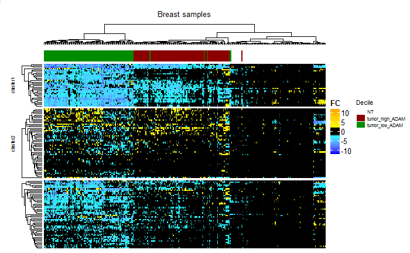

```r
Liste=list(Decile=c("NT"="white", "tumor_high_ADAM"="red4", "tumor_low_ADAM"="green4"))

ha= HeatmapAnnotation(df = Label_col,
                       col =  Liste,
                       annotation_legend_param = list(title_gp = gpar(fontsize = 8),
        labels_gp = gpar(fontsize = 6),grid_height = unit(3, "mm")),
        annotation_height =unit(0.5, "cm"))


#Premiere heatmap SEIN
#ComplexHeatmap::Heatmap(as.matrix(breastsubADAM_TAK1_norm_tot))


Heatmap(as.matrix(log2(breastsubADAM_TAK1_norm_tot)),
   name="FC",
   cluster_columns = TRUE,
    clustering_distance_columns = "euclidean",
    clustering_method_columns = "ward.D2",
   column_title = "Breast samples", #titre
   column_title_gp = gpar(fontsize = 10),
    km = 3,
   row_title_gp = gpar(fontsize = c(6,6)),
    show_column_names = FALSE, #pas de nom des éch
    show_row_names = FALSE, #ni des gènes
    top_annotation = ha, #en top, les anno Cancer / NT etc
   top_annotation_height = unit(0.7, "cm"),
    show_heatmap_legend = TRUE,
  col = colorRamp2(c(-10,-2,-1.5, 0,1.5,2, 10), c("blue","cyan","black", "black","black","yellow", "orange"))
    #heatmap_legend_param = list(legend_direction = "vertical",
    #legend_width = unit(3, "cm"), title_position = "topcenter",fontsize = 6)
) #on ajoute les anno lignes
```

```r
NA
NA
```

## Corrélation

```r
equation = function(x) {
  lm_coef <- list(r = round(x$r[1,2], digits = 2),
                  P = x$P[1,2]);
  lm_eq <- substitute(bold(Pearson)*":"~~italic(R) == r*","~~italic(pvalue)~"="~P,lm_coef)
  as.character(as.expression(lm_eq));
}
```

```r
A=dds_tableTOT_breast[which(rownames(dds_tableTOT_breast)=="ADAM12"),]

Type=rep("Int", dim(dds_tableTOT_breast)[2])
Type[which(A>=quantile(A, na.rm=T, 0.9))]="High"
Type[which(A<=quantile(A, na.rm=T, 0.1))]="Low"
Type=Type[-which(clab_breast=="Solid Tissue Normal")]
Type=as.factor(Type)

for (i in c(1:dim(ADAM_TAK1_b)[2])) {
  ADAM_TAK1_b[which(ADAM_TAK1_b[,i]==Inf),i]=NA
    ADAM_TAK1_b[which(log2(ADAM_TAK1_b[,i])==-Inf),i]=NA
   ADAM_TAK1_b[which(is.nan(ADAM_TAK1_b[,i])==T),i]=NA
}


MafonctionSum=function(X){
  X=sum(X, na.rm =TRUE)
}

Tak1_all=apply((log2(ADAM_TAK1_b)),
               2,
               MafonctionSum)

Adam=dds_tableTOT_breast[which(rownames(dds_tableTOT_breast)=="ADAM12"),]


#Score TAK1 par colonne

data=data.frame(Tak=Tak1_all,
           Adam=t(Adam),
           Type=Type)
colnames(data)=c("Tak","Adam", "Type")
head(data)
```

|  | Tak | Adam | Type |
| --- | --- | --- | --- |
| X1AB92ADA.637E.4A42.A39A.70CEEEA41AE3 | -47.8601719 | 125491.53 | Int |
| DA98A67C.F11F.41D3.8223.1161EBFF8B58 | 13.4638965 | 54872.02 | Low |
| X06CCFD0F.7FB8.471E.B823.C7876582D6FC | 86.6219374 | 1627478.24 | High |
| A33B2F42.6EC6.4FB2.8BE5.542407A0382E | 0.2835957 | 318096.46 | Int |
| CC4C52A7.57D4.4959.ABFB.8ED3B1BA4DED | 114.2304103 | 2134763.03 | High |
| D021A258.8713.4383.9DCA.45E2F54A0411 | 101.1940384 | 1435764.45 | High |

```r
equation = function(x) {
  lm_coef <- list(r = round(x$r[1,2], digits = 2),
                  P = x$P[1,2]);
  lm_eq <- substitute(bold(Pearson)*":"~~italic(R) == r*","~~italic(pvalue)~"="~P,lm_coef)
  as.character(as.expression(lm_eq));
}
```

```r
#Coeff de corrélation
xm = as.matrix(data[,1:2])
#head(xm[,])
library("Hmisc")

M <-  rcorr(xm, type = "pearson")
M
```

```
      Tak Adam
Tak  1.00 0.69
Adam 0.69 1.00

n= 1246


P
     Tak Adam
Tak       0
Adam  0
```

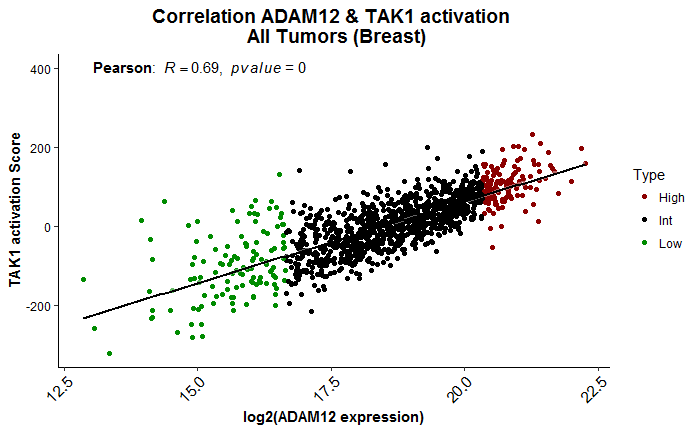

```r
TAK1_ADAM12=M$r[1,2]

library(ggplot2)
ggplot(data=data, aes(x=log2(Adam), y=Tak, color=Type))+
  geom_point()+
  geom_smooth(colour = "black",fill="white", method = "lm") +
  scale_color_manual(values=c("red4", "black","green4"))+
  labs(title="Correlation ADAM12 & TAK1 activation \n All Tumors (Breast)", y="TAK1 activation Score",x="log2(ADAM12 expression)",cex=10)+
  theme_classic()+
 theme(plot.title = element_text(size = 14, face = "bold",hjust = 0.5),
              text=element_text(),
              axis.title = element_text(face="bold"),
              axis.text.x=element_text(angle=45, hjust=1,colour="black", size = 11),
              axis.text.y=element_text(colour="black", size = 9))+
      annotate("text", x = 15.05, y = 400.05, label = equation(M), parse = TRUE)
```

##Corrélation KAT2A /TAK1

```r
A=dds_tableTOT_breast[which(rownames(dds_tableTOT_breast)=="KAT2A"),]

Type=rep("Int", dim(dds_tableTOT_breast)[2])
Type[which(A>=quantile(A, na.rm=T, 0.9))]="High"
Type[which(A<=quantile(A, na.rm=T, 0.1))]="Low"
Type=Type[-which(clab_breast=="Solid Tissue Normal")]
Type=as.factor(Type)

KAT2A=dds_tableTOT_breast[which(rownames(dds_tableTOT_breast)=="KAT2A"),]


#Score TAK1 par colonne

data=data.frame(Tak=Tak1_all,
           KAT2A=t(KAT2A),
           Type=Type)
colnames(data)=c("Tak","KAT2A", "Type")
head(data)
```

|  | Tak | KAT2A | Type |
| --- | --- | --- | --- |
| X1AB92ADA.637E.4A42.A39A.70CEEEA41AE3 | -47.8601719 | 235548.30 | Int |
| DA98A67C.F11F.41D3.8223.1161EBFF8B58 | 13.4638965 | 249909.74 | Int |
| X06CCFD0F.7FB8.471E.B823.C7876582D6FC | 86.6219374 | 65981.18 | Low |
| A33B2F42.6EC6.4FB2.8BE5.542407A0382E | 0.2835957 | 235737.45 | Int |
| CC4C52A7.57D4.4959.ABFB.8ED3B1BA4DED | 114.2304103 | 575486.95 | High |
| D021A258.8713.4383.9DCA.45E2F54A0411 | 101.1940384 | 209037.10 | Int |

```r
#Coeff de corrélation
xm = as.matrix(data[,1:2])
#head(xm[,])
library("Hmisc")

M <-  rcorr(xm, type = "pearson")
M
```

```
        Tak KAT2A
Tak    1.00 -0.44
KAT2A -0.44  1.00

n= 1246


P
      Tak KAT2A
Tak        0
KAT2A  0
```

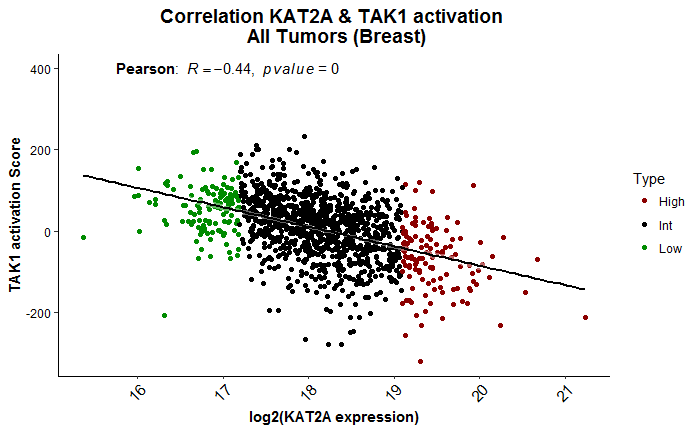

```r
TAK1_KAT2A=M$r[1,2]

library(ggplot2)
ggplot(data=data, aes(x=log2(KAT2A), y=Tak, color=Type))+
  geom_point()+
  geom_smooth(colour = "black",fill="white", method = "lm") +
  scale_color_manual(values=c("red4", "black","green4"))+
  labs(title="Correlation KAT2A & TAK1 activation \n All Tumors (Breast)", y="TAK1 activation Score",x="log2(KAT2A expression)",cex=10)+
  theme_classic()+
 theme(plot.title = element_text(size = 14, face = "bold",hjust = 0.5),
              text=element_text(),
              axis.title = element_text(face="bold"),
              axis.text.x=element_text(angle=45, hjust=1,colour="black", size = 11),
              axis.text.y=element_text(colour="black", size = 9))+
      annotate("text", x = 17.05, y = 400.05, label = equation(M), parse = TRUE)
```

##???SIRT6

```r
A=dds_tableTOT_breast[which(rownames(dds_tableTOT_breast)=="SIRT6"),]

Type=rep("Int", dim(dds_tableTOT_breast)[2])
Type[which(A>=quantile(A, na.rm=T, 0.9))]="High"
Type[which(A<=quantile(A, na.rm=T, 0.1))]="Low"
Type=Type[-which(clab_breast=="Solid Tissue Normal")]
Type=as.factor(Type)

SIRT6=dds_tableTOT_breast[which(rownames(dds_tableTOT_breast)=="SIRT6"),]


#Score TAK1 par colonne

data=data.frame(Tak=Tak1_all,
           SIRT6=t(SIRT6),
           Type=Type)
colnames(data)=c("Tak","SIRT6", "Type")
head(data)

#Coeff de corrélation
xm = as.matrix(data[,1:2])
#head(xm[,])
library("Hmisc")

M <-  rcorr(xm, type = "pearson")
M
library(ggplot2)
ggplot(data=data, aes(x=log2(SIRT6), y=Tak, color=Type))+
  geom_point()+
  geom_smooth(colour = "black",fill="white", method = "lm") +
  scale_color_manual(values=c("red4", "black","green4"))+
  labs(title="Correlation SIRT6 & TAK1 activation \n All Tumors (Breast)", y="TAK1 activation Score",x="log2(SIRT6 expression)",cex=10)+
  theme_classic()+
 theme(plot.title = element_text(size = 14, face = "bold",hjust = 0.5),
              text=element_text(),
              axis.title = element_text(face="bold"),
              axis.text.x=element_text(angle=45, hjust=1,colour="black", size = 11),
              axis.text.y=element_text(colour="black", size = 9))+
      annotate("text", x = 17.05, y = 400.05, label = equation(M), parse = TRUE)
```

##.Pie chart

```r
library("gridExtra")

data=data.frame(class=c("TAK1-independant", "TAK1-dependant"),
                Num=round(c(171,339)/c(171+339),2))
data


theme_update(panel.background = element_blank(),
             panel.grid.major= element_blank(),
             panel.grid.minor = element_blank(),
             axis.text.x = element_blank(),
             axis.text.y = element_blank(),
             axis.ticks.y = element_blank(),
             axis.ticks.x = element_blank(),
             axis.title.y = element_blank(),
             axis.title.x = element_blank(),
             legend.position="right",
             legend.text=element_text(size=10),
             legend.title=element_text(size=10))

ggTS_NT=ggplot(data = data, mapping = aes(x = factor(1), y = Num, fill = class)) +
  geom_bar(width=1, stat = "identity", color="black") +
  coord_polar(theta = "y") +
  scale_fill_manual(values=c("goldenrod3", "grey70"))+
  geom_text(aes(x = c(1, 1), #jouer sur ce paramètre pour placer les légendes : distance au centre
                y = Num/2 + c(0, cumsum(Num)[-length(Num)]),
                label=paste(Num*100, "%")), family = "Consolas",
            color=c("black", "black"))+
  ggtitle("TAK1 target genes")+
   theme(
         legend.direction   = "vertical",
         plot.title = element_text(size = 14, face = "bold",hjust = 0.5))


grid.arrange(ggTS_NT,
             ncol=1, nrow=1)
```

## heatmap Colon

```r
CRCsubADAM_TAK1_norm_tot=subADAM_TAK1_norm_tot[,which(as.data.frame(clab_ADAM_tot)$Tissue=="CRC")]
Label_col=data.frame(Decile=(rep(NA,dim(clab_ADAM_tot[which(as.data.frame(clab_ADAM_tot)$Tissue=="CRC"),])[1] )))
Label_col$Decile[which(as.data.frame(clab_ADAM_tot[which(as.data.frame(clab_ADAM_tot)$Tissue=="CRC"),])$Decile=="NT")]="white"
Label_col$Decile[which(as.data.frame(clab_ADAM_tot[which(as.data.frame(clab_ADAM_tot)$Tissue=="CRC"),])$Decile=="tumor_high_ADAM")]="black"
Label_col$Decile[which(as.data.frame(clab_ADAM_tot[which(as.data.frame(clab_ADAM_tot)$Tissue=="CRC"),])$Decile=="tumor_low_ADAM")]="grey"

CRCrow_names <- rep(" ", nrow(subADAM_TAK1_norm_tot))
CRCrow_names[which(is.element(rownames(subADAM_TAK1_norm_tot), c("ADAM12"))==TRUE)]="ADAM12"

#Les clsuters
Colv  <- log2(as.matrix(1+CRCsubADAM_TAK1_norm_tot)) %>% na.omit %>%  t %>% dist %>% hclust(method="ward.D") %>% as.dendrogram %>%
   set("branches_k_color", k = 3, value = rep(c("black", "grey50","grey80"),3)) %>%
   set("branches_lwd", 1.2) %>%
   ladderize


heatmap.3(na.omit(log2(as.matrix(CRCsubADAM_TAK1_norm_tot+1))),#on passe au log2 pour centrer la distribiution
          main="TAK1 signature _ CRC",
          ColSideColorsSize=2,
          Colv=Colv,
          breaks = col_breaks,
          ColSideColors = as.matrix(Label_col$Decile), #Pour indiquer la nature de lechantillon
          col = colorRamp2(c(-10,-2,-1, 0,1,2, 10),
                           c("blue","cyan","black", "black","black","yellow", "orange")),
          dendrogram="col",     # only draw a row dendrogram
          key=TRUE,
          density.info="histogram",
          labRow = CRCrow_names,
          cexRow=0.5,
          labCol=FALSE,
          margins = c(10,15))
legend("topright",legend=c("Normal","Tumor_high ADAM12","Tumor_low ADAM12"),
fill=c("white","black","grey"), border=TRUE, bty="n", y.intersp = 0.7, cex=0.7)
```

```r
breastsubADAM_TAK1_norm_tot=subADAM_TAK1_norm_tot[,which(as.data.frame(clab_ADAM_tot)$Tissue=="breast")]
Label_col=data.frame(Decile=(rep(NA,dim(clab_ADAM_tot[which(as.data.frame(clab_ADAM_tot)$Tissue=="breast"),])[1] )))
Label_col$Decile[which(as.data.frame(clab_ADAM_tot[which(as.data.frame(clab_ADAM_tot)$Tissue=="breast"),])$Decile=="NT")]="white"
Label_col$Decile[which(as.data.frame(clab_ADAM_tot[which(as.data.frame(clab_ADAM_tot)$Tissue=="breast"),])$Decile=="tumor_high_ADAM")]="black"
Label_col$Decile[which(as.data.frame(clab_ADAM_tot[which(as.data.frame(clab_ADAM_tot)$Tissue=="breast"),])$Decile=="tumor_low_ADAM")]="grey"

breastrow_names <- rep(" ", nrow(subADAM_TAK1_norm_tot))
breastrow_names[which(is.element(rownames(subADAM_TAK1_norm_tot), c("ADAM12"))==TRUE)]="ADAM12"

#Les clsuters
Colv  <- log2(as.matrix(1+breastsubADAM_TAK1_norm_tot)) %>% na.omit %>%  t %>% dist %>% hclust(method="ward.D2") %>% as.dendrogram %>%
   set("branches_k_color", k = 3, value = rep(c("black", "grey50","grey80"),3)) %>%
   set("branches_lwd", 1.2) %>%
   ladderize


heatmap.3(na.omit(log2(as.matrix(breastsubADAM_TAK1_norm_tot+1))),#on passe au log2 pour centrer la distribiution
          main="TAK1 signature _ BREAST",
          ColSideColorsSize=2,
          Colv=Colv,
          breaks = col_breaks,
          ColSideColors = as.matrix(Label_col$Decile), #Pour indiquer la nature de lechantillon
          col=my_palette,
          dendrogram="col",     # only draw a row dendrogram
          key=TRUE,
          density.info="histogram",
          labRow = breastrow_names,
          cexRow=0.5,
          labCol=FALSE,
          margins = c(10,15))
legend("topright",legend=c("Normal","Tumor_high ADAM12","Tumor_low ADAM12"),
fill=c("white","black","grey"), border=TRUE, bty="n", y.intersp = 0.7, cex=0.7)
```

```r
lungsubADAM_TAK1_norm_tot=subADAM_TAK1_norm_tot[,which(as.data.frame(clab_ADAM_tot)$Tissue=="lung")]
Label_col=data.frame(Decile=(rep(NA,dim(clab_ADAM_tot[which(as.data.frame(clab_ADAM_tot)$Tissue=="lung"),])[1] )))
Label_col$Decile[which(as.data.frame(clab_ADAM_tot[which(as.data.frame(clab_ADAM_tot)$Tissue=="lung"),])$Decile=="NT")]="white"
Label_col$Decile[which(as.data.frame(clab_ADAM_tot[which(as.data.frame(clab_ADAM_tot)$Tissue=="lung"),])$Decile=="tumor_high_ADAM")]="black"
Label_col$Decile[which(as.data.frame(clab_ADAM_tot[which(as.data.frame(clab_ADAM_tot)$Tissue=="lung"),])$Decile=="tumor_low_ADAM")]="grey"

lungrow_names <- rep(" ", nrow(subADAM_TAK1_norm_tot))
lungrow_names[which(is.element(rownames(subADAM_TAK1_norm_tot), c("ADAM12"))==TRUE)]="ADAM12"

#Les clsuters
Colv  <- log2(as.matrix(1+lungsubADAM_TAK1_norm_tot)) %>% na.omit %>%  t %>% dist %>% hclust(method="ward.D2") %>% as.dendrogram %>%
   set("branches_k_color", k = 3, value = rep(c("black", "grey50","grey80"),3)) %>%
   set("branches_lwd", 1.2) %>%
   ladderize


heatmap.3(na.omit(log2(as.matrix(lungsubADAM_TAK1_norm_tot+1))),#on passe au log2 pour centrer la distribiution
          main="TAK1 signature _ LUNG",
          ColSideColorsSize=2,
          Colv=Colv,
          breaks = col_breaks,
          ColSideColors = as.matrix(Label_col$Decile), #Pour indiquer la nature de lechantillon
          col=my_palette,
          dendrogram="col",     # only draw a row dendrogram
          key=TRUE,
          density.info="histogram",
          labRow = lungrow_names,
          cexRow=0.5,
          labCol=FALSE,
          margins = c(10,15))
legend("topright",legend=c("Normal","Tumor_high ADAM12","Tumor_low ADAM12"),
fill=c("white","black","grey"), border=TRUE, bty="n", y.intersp = 0.7, cex=0.7)
```

#**Expression relative de KAT2A et SIRT6 :** ____________________________________________

```r
geneint=c("ADAM12","COL6A1","COL6A2","COL6A3","MAP3K7","SIRT6","KAT2A","CDKN2B","CDKN1A","CDKN1B","IL6","SMAD7","CDC25A","MYC","ID1","ID2","ID3", "CLDN3","CLDN4","CLDN7","CDH1","CDH2","TJP1","DSP","VIM","ESR1","PGR","ERBB2","TGFB1","COL1A1","MMP2","ZBTB4","ADAM19")
subADAM_table_CRC=ComparADAM_ddsTOT_CRC[which(is.element(rownames(ComparADAM_ddsTOT_CRC), geneint)==TRUE),]
subADAM_table_NT_CRC=ComparADAM_ddsTOT_NT_CRC[which(is.element(rownames(ComparADAM_ddsTOT_NT_CRC), geneint)==TRUE),]

subADAM_table_lung=ComparADAM_ddsTOT_lung[which(is.element(rownames(ComparADAM_ddsTOT_lung), geneint)==TRUE),]
subADAM_table_NT_lung=ComparADAM_ddsTOT_NT_lung[which(is.element(rownames(ComparADAM_ddsTOT_NT_lung), geneint)==TRUE),]

subADAM_table_breast=ComparADAM_ddsTOT_breast[which(is.element(rownames(ComparADAM_ddsTOT_breast), geneint)==TRUE),]
subADAM_table_NT_breast=ComparADAM_ddsTOT_NT_breast[which(is.element(rownames(ComparADAM_ddsTOT_NT_breast), geneint)==TRUE),]

gene=rownames(subADAM_table_CRC)

#colonne Decile pour nv exp ADAM, gene pour nom des gènes
subADAM_CRC=data.frame(stack(subADAM_table_CRC),
                   Decile=c(rep("NT",length(ADAM_NT_CRC)*length(gene)),
                         rep("tumor_low_ADAM12",length(low_ADAM_CRC)*length(gene)),
                         rep("tumor_high_ADAM12",length(high_ADAM_CRC)*length(gene))),
                   Gene=rep(gene, sum(length(ADAM_NT_CRC),length(low_ADAM_CRC),length(high_ADAM_CRC))))

subADAM_lung=data.frame(stack(subADAM_table_lung),
                   Decile=c(rep("NT",length(ADAM_NT_lung)*length(gene)),
                         rep("tumor_low_ADAM12",length(low_ADAM_lung)*length(gene)),
                         rep("tumor_high_ADAM12",length(high_ADAM_lung)*length(gene))),
                   Gene=rep(gene, sum(length(ADAM_NT_lung),length(low_ADAM_lung),length(high_ADAM_lung))))

subADAM_breast=data.frame(stack(subADAM_table_breast),
                   Decile=c(rep("NT",length(ADAM_NT_breast)*length(gene)),
                         rep("tumor_low_ADAM12",length(low_ADAM_breast)*length(gene)),
                         rep("tumor_high_ADAM12",length(high_ADAM_breast)*length(gene))),
                   Gene=rep(gene, sum(length(ADAM_NT_breast),length(low_ADAM_breast),length(high_ADAM_breast))))


#on veut calculer un FC tumeur contre tissu normal
MeanNT_A12_CRC=c()#on calcule la median des scores MCP pour les tissus normaux
for (i in seq(1,length(gene))) {
  MeanNT_A12_CRC=c(MeanNT_A12_CRC, geometric.mean(as.matrix(subADAM_table_NT_CRC)[i,]))
}
for(i in seq(1, dim(subADAM_CRC)[1])) {
subADAM_CRC$values[i]=subADAM_CRC$values[i]/rep(MeanNT_A12_CRC,(sum(length(ADAM_NT_CRC),length(low_ADAM_CRC),length(high_ADAM_CRC))))[i]
}

MeanNT_A12_lung=c()
for (i in seq(1,length(gene))) {
  MeanNT_A12_lung=c(MeanNT_A12_lung, geometric.mean(as.matrix(subADAM_table_NT_lung)[i,]))
}
for(i in seq(1, dim(subADAM_lung)[1])) {
subADAM_lung$values[i]=subADAM_lung$values[i]/rep(MeanNT_A12_lung,(sum(length(ADAM_NT_lung),length(low_ADAM_lung),length(high_ADAM_lung))))[i]
}
MeanNT_A12_breast=c()
for (i in seq(1,length(gene))) {
  MeanNT_A12_breast=c(MeanNT_A12_breast, geometric.mean(as.matrix(subADAM_table_NT_breast)[i,]))
}
for(i in seq(1, dim(subADAM_breast)[1])) {
subADAM_breast$values[i]=subADAM_breast$values[i]/rep(MeanNT_A12_breast,(sum(length(ADAM_NT_breast),length(low_ADAM_breast),length(high_ADAM_breast))))[i]
}

#On assemble le tout
subADAM_tot=data.frame(rbind(subADAM_CRC,subADAM_lung,subADAM_breast),
                       Type=c(rep("COAD",dim(subADAM_CRC)[1]),
                              rep("LUNG",dim(subADAM_lung)[1]),
                              rep("BREAST",dim(subADAM_breast)[1])))





ggplot(subADAM_tot[which(is.element(subADAM_tot$Gene,c("ADAM12"))==TRUE),],
       aes(x=Type, y=log2(values), fill=Decile))+
    geom_boxplot(position = position_dodge(0.9), notch=TRUE)+
  stat_summary(fun.y=mean, geom="point", shape=18,
                size=4, color="black",position = position_dodge(0.9))+
            geom_hline(yintercept=0, linetype="dashed", color = "grey10")+
  labs(title="ADAM12", y="log2(FC)",x=" ",cex=10)+
  theme_classic()+
  theme(plot.title = element_text(size = 14, face = "bold",hjust=0.5),
              text=element_text(),
              axis.title = element_text(face="bold"),
              axis.text.x=element_text(angle=45, hjust=1,colour="black", size = 11),
              axis.text.y=element_text(colour="black", size = 9))+
 scale_fill_manual(values=c("white","red4","green4"))+
  scale_x_discrete(limits=c(
    #"COAD","","LUNG","",
                           "", "BREAST",""))
```

```r
ggplot(subADAM_tot[which(is.element(subADAM_tot$Gene,c("MAP3K7"))==TRUE),],
       aes(x=Type, y=log2(values), fill=Decile))+
    geom_boxplot(position = position_dodge(0.9), notch=TRUE)+
  stat_summary(fun.y=mean, geom="point", shape=18,
                size=4, color="black",position = position_dodge(0.9))+
            geom_hline(yintercept=0, linetype="dashed", color = "grey10")+
  labs(title="TAK1", y="log2(FC)",x=" ",cex=10)+
  theme_classic()+
  theme(plot.title = element_text(size = 14, face = "bold",hjust=0.5),
              text=element_text(),
              axis.title = element_text(face="bold"),
              axis.text.x=element_text(angle=45, hjust=1,colour="black", size = 11),
              axis.text.y=element_text(colour="black", size = 9))+
 scale_fill_manual(values=c("white","red4","green4"))+
  scale_x_discrete(limits=c(
   # "COAD","","LUNG","",
    "","BREAST",""))
```

```r
ggplot(subADAM_tot[which(is.element(subADAM_tot$Gene,c("KAT2A"))==TRUE),],
       aes(x=Type, y=log2(values), fill=Decile))+
    geom_boxplot(position = position_dodge(0.9), notch=TRUE)+
  stat_summary(fun.y=mean, geom="point", shape=18,
                size=4, color="black",position = position_dodge(0.9))+
            geom_hline(yintercept=0, linetype="dashed", color = "grey10")+
  labs(title="KAT2A", y="log2(FC)",x=" ",cex=10)+
  theme_classic()+
  theme(plot.title = element_text(size = 14, face = "bold",hjust=0.5),
              text=element_text(),
              axis.title = element_text(face="bold"),
              axis.text.x=element_text(angle=45, hjust=1,colour="black", size = 11),
              axis.text.y=element_text(colour="black", size = 9))+
 scale_fill_manual(values=c("white","red4","green4"))+
  scale_x_discrete(limits=c(
   # "COAD","","LUNG","",
   "" , "BREAST", ""))
```

```r
A=dds_tableTOT_breast[which(rownames(dds_tableTOT_breast)=="MAP3K7"),]
Quant2=rep(NA, dim(dds_tableTOT_breast)[2])
Quant2[which(A>=quantile(A, na.rm=T, 0.5))]="High"
#Quant2[which(A<quantile(A, na.rm=T, 0.75))]="Int"
Quant2[which(A<=quantile(A, na.rm=T, 0.5))]="Low"
mydata=data.frame(time=Suivi_progression[which(Type_sample!="Solid Tissue Normal"&ClassTum=="Triple-negative")],
                  status=status_recidive[which(Type_sample!="Solid Tissue Normal"&ClassTum=="Triple-negative")],
                  Decile=Quant2[which(Type_sample!="Solid Tissue Normal"&ClassTum=="Triple-negative")])
# List of ggsurvplots
splots <- list()
fit_recid=survfit(Surv(time,status)~Decile,data=mydata)
splots[[1]] <- ggsurvplot(fit_recid, data = mydata,
   legend = "bottom",
   legend.title = "Breast",
   legend.labs = c("High", "Low"),
   palette = c("red4", "green4"),
   font.x = c(10),
   font.y = c(10),
   main="Survie sans récidive TSP Nat Com",
   pval = TRUE,
              risk.table = TRUE,   surv.median.line=c("v"),
              tables.y.text = FALSE,
              ggtheme = theme_classic())
#2e plot = survie globale
mydata2=data.frame(time=Suivi_Mort[which(Type_sample!="Solid Tissue Normal"&ClassTum=="Triple-negative")],
                  status=status_mort[which(Type_sample!="Solid Tissue Normal"&ClassTum=="Triple-negative")],
                  Decile=Quant2[which(Type_sample!="Solid Tissue Normal"&ClassTum=="Triple-negative")])
summary(as.factor(mydata$status))
```

```
 0  1
83 37
```

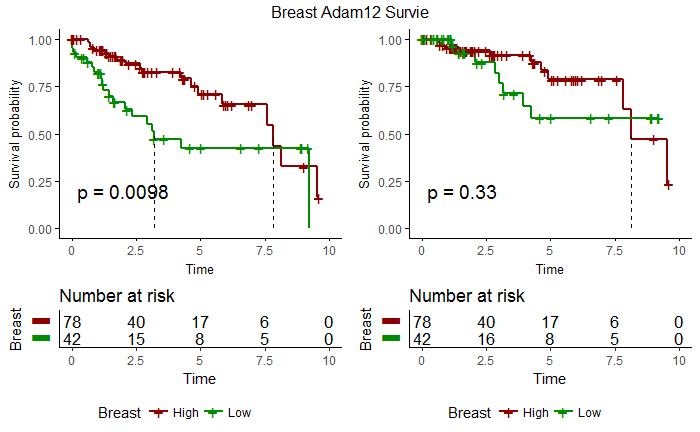

```r
fit_mort=survfit(Surv(time,status)~Decile,data=mydata2)
splots[[2]] <- ggsurvplot(fit_mort, data = mydata2,
   legend = "bottom",
   legend.title = "Breast",
  legend.labs = c("High", "Low"),
   palette = c("red4","green4"),
   font.x = c(10),
   font.y = c(10),
   main="Survie sans récidive TSP Nat Com",
   pval = TRUE,
              risk.table = TRUE,   surv.median.line=c("v"),
              tables.y.text = FALSE,
              ggtheme = theme_classic())

# Arrange multiple ggsurvplots and print the output
arrange_ggsurvplots(splots, print = TRUE, title="Breast Adam12 Survie",
  ncol = 2, nrow = 1, risk.table.height = 0.3)
```

#TESTS STATS _______________________

#en changeant SIRT6 MAP3K7 KAT2A ADAM12

```r
summary(aov(values ~ Decile, subset(subset(subADAM_tot, Gene %in% "ADAM12"),
              Type %in% "BREAST")))
```

```r
#install.packages('PMCMRplus')
library(PMCMRplus)
#?tukeyTest

summary(tukeyTest(values ~ Decile, subset(subset(subADAM_tot, Gene %in% "ADAM12"),
              Type %in% "BREAST")))
```

#Breast TN A²12 NT / Tum —————-

```r
B=which(ClassTum=="Triple-negative")

Type=rep(NA, length(clab_breast$Type))
Type[which(is.element(clab_breast$Type, c("Solid Tissue Normal"))==TRUE)]="Solid Tissue Normal"
Type[which(is.element(clab_breast$Type, c("Primary Tumor", "Metastatic"))==TRUE)]="Tumor"

head(data.frame(stack(dds_tableTOT_breast[which(rownames(dds_tableTOT_breast)=="ADAM12"),B]/median(ADAM_NT_breast)),
                       Type[B]))


ggplot(data=data.frame(stack(dds_tableTOT_breast[which(rownames(dds_tableTOT_breast)=="ADAM12"),B]/median(ADAM_NT_breast)),
                       Type[B]),
       aes(x=Type, y=log2(values), fill=Type))+
    geom_boxplot(position = position_dodge(0.9), notch=TRUE)+
  stat_summary(fun.y=mean, geom="point", shape=18,
                size=2, color="black",position = position_dodge(0.9))+
            geom_hline(yintercept=0, linetype="dashed", color = "grey")+
  labs(title="ADAM12 Breast TN", y="log2(FC) /SNT",x=" ",cex=10)+
  theme_classic()+
  theme(plot.title = element_text(size = 14, face = "bold",hjust=0.5),
              text=element_text(),
              axis.title = element_text(face="bold"),
              axis.text.x=element_text(angle=45, hjust=1,colour="black", size = 11),
              axis.text.y=element_text(colour="black", size = 9))+
  scale_x_discrete(limits=c("","Solid Tissue Normal","Tumor",""))+
  scale_fill_manual(values=c("white","black"))
```

## Courbe de survie selon expression ADAM12

```r
A=dds_tableTOT_breast[which(rownames(dds_tableTOT_breast)=="ADAM12"),]

Quant2=rep(NA, dim(dds_tableTOT_breast)[2])
Quant2[which(A>=quantile(A, na.rm=T, 0.5))]="High"
#Quant2[which(A<quantile(A, na.rm=T, 0.75))]="Int"
Quant2[which(A<=quantile(A, na.rm=T, 0.5))]="Low"

mydata=data.frame(time=Suivi_progression[which(Type_sample!="Solid Tissue Normal"&ClassTum=="Triple-negative")],
                  status=status_recidive[which(Type_sample!="Solid Tissue Normal"&ClassTum=="Triple-negative")],
                  Decile=Quant2[which(Type_sample!="Solid Tissue Normal"&ClassTum=="Triple-negative")])

# List of ggsurvplots
splots <- list()

fit_recid=survfit(Surv(time,status)~Decile,data=mydata)

splots[[1]] <- ggsurvplot(fit_recid, data = mydata,
   legend = "bottom",
   legend.title = "Breast",
   legend.labs = c("High", "Low"),
   palette = c("red4", "green4"),
   font.x = c(10),
   font.y = c(10),
   main="Survie sans récidive TSP Nat Com",
   pval = TRUE,
              risk.table = TRUE,   surv.median.line=c("v"),
              tables.y.text = FALSE,
              ggtheme = theme_classic())

#2e plot = survie globale
mydata2=data.frame(time=Suivi_Mort[which(Type_sample!="Solid Tissue Normal"&ClassTum=="Triple-negative")],
                  status=status_mort[which(Type_sample!="Solid Tissue Normal"&ClassTum=="Triple-negative")],
                  Decile=Quant2[which(Type_sample!="Solid Tissue Normal"&ClassTum=="Triple-negative")])
summary(as.factor(mydata$status))

fit_mort=survfit(Surv(time,status)~Decile,data=mydata2)

splots[[2]] <- ggsurvplot(fit_mort, data = mydata2,
   legend = "bottom",
   legend.title = "Breast",
  legend.labs = c("High", "Low"),
   palette = c("red4","green4"),
   font.x = c(10),
   font.y = c(10),
   main="Survie sans récidive TSP Nat Com",
   pval = TRUE,
              risk.table = TRUE,   surv.median.line=c("v"),
              tables.y.text = FALSE,
              ggtheme = theme_classic())

# Arrange multiple ggsurvplots and print the output
arrange_ggsurvplots(splots, print = TRUE, title="Breast Adam12 Survie",
  ncol = 2, nrow = 1, risk.table.height = 0.3)
```

## survioe TAK1

```r
A=dds_tableTOT_breast[which(rownames(dds_tableTOT_breast)=="MAP3K7"),]

Quant2=rep(NA, dim(dds_tableTOT_breast)[2])
Quant2[which(A>=quantile(A, na.rm=T, 0.5))]="High"
#Quant2[which(A<quantile(A, na.rm=T, 0.75))]="Int"
Quant2[which(A<=quantile(A, na.rm=T, 0.5))]="Low"

mydata=data.frame(time=Suivi_progression[which(Type_sample!="Solid Tissue Normal"&ClassTum=="Triple-negative")],
                  status=status_recidive[which(Type_sample!="Solid Tissue Normal"&ClassTum=="Triple-negative")],
                  Decile=Quant2[which(Type_sample!="Solid Tissue Normal"&ClassTum=="Triple-negative")])

# List of ggsurvplots
splots <- list()

fit_recid=survfit(Surv(time,status)~Decile,data=mydata)

splots[[1]] <- ggsurvplot(fit_recid, data = mydata,
   legend = "bottom",
   legend.title = "Breast",
   legend.labs = c("High", "Low"),
   palette = c("red4", "green4"),
   font.x = c(10),
   font.y = c(10),
   main="Survie sans récidive TSP Nat Com",
   pval = TRUE,
              risk.table = TRUE,   surv.median.line=c("v"),
              tables.y.text = FALSE,
              ggtheme = theme_classic())

#2e plot = survie globale
mydata2=data.frame(time=Suivi_Mort[which(Type_sample!="Solid Tissue Normal"&ClassTum=="Triple-negative")],
                  status=status_mort[which(Type_sample!="Solid Tissue Normal"&ClassTum=="Triple-negative")],
                  Decile=Quant2[which(Type_sample!="Solid Tissue Normal"&ClassTum=="Triple-negative")])
summary(as.factor(mydata$status))

fit_mort=survfit(Surv(time,status)~Decile,data=mydata2)

splots[[2]] <- ggsurvplot(fit_mort, data = mydata2,
   legend = "bottom",
   legend.title = "Breast",
  legend.labs = c("High", "Low"),
   palette = c("red4","green4"),
   font.x = c(10),
   font.y = c(10),
   main="Survie sans récidive TSP Nat Com",
   pval = TRUE,
              risk.table = TRUE,   surv.median.line=c("v"),
              tables.y.text = FALSE,
              ggtheme = theme_classic())

# Arrange multiple ggsurvplots and print the output
arrange_ggsurvplots(splots, print = TRUE, title="Breast Adam12 Survie",
  ncol = 2, nrow = 1, risk.table.height = 0.3)
```

## Survie KAT2A

```r
A=dds_tableTOT_breast[which(rownames(dds_tableTOT_breast)=="KAT2A"),]

Quant2=rep(NA, dim(dds_tableTOT_breast)[2])
Quant2[which(A>=quantile(A, na.rm=T, 0.5))]="High"
#Quant2[which(A<quantile(A, na.rm=T, 0.75))]="Int"
Quant2[which(A<=quantile(A, na.rm=T, 0.5))]="Low"

mydata=data.frame(time=Suivi_progression[which(Type_sample!="Solid Tissue Normal"&ClassTum=="Triple-negative")],
                  status=status_recidive[which(Type_sample!="Solid Tissue Normal"&ClassTum=="Triple-negative")],
                  Decile=Quant2[which(Type_sample!="Solid Tissue Normal"&ClassTum=="Triple-negative")])

# List of ggsurvplots
splots <- list()

fit_recid=survfit(Surv(time,status)~Decile,data=mydata)

splots[[1]] <- ggsurvplot(fit_recid, data = mydata,
   legend = "bottom",
   legend.title = "Breast",
   legend.labs = c("High", "Low"),
   palette = c("red4", "green4"),
   font.x = c(10),
   font.y = c(10),
   main="Survie sans récidive TSP Nat Com",
   pval = TRUE,
              risk.table = TRUE,   surv.median.line=c("v"),
              tables.y.text = FALSE,
              ggtheme = theme_classic())

#2e plot = survie globale
mydata2=data.frame(time=Suivi_Mort[which(Type_sample!="Solid Tissue Normal"&ClassTum=="Triple-negative")],
                  status=status_mort[which(Type_sample!="Solid Tissue Normal"&ClassTum=="Triple-negative")],
                  Decile=Quant2[which(Type_sample!="Solid Tissue Normal"&ClassTum=="Triple-negative")])
summary(as.factor(mydata$status))

fit_mort=survfit(Surv(time,status)~Decile,data=mydata2)

splots[[2]] <- ggsurvplot(fit_mort, data = mydata2,
   legend = "bottom",
   legend.title = "Breast",
  legend.labs = c("High", "Low"),
   palette = c("red4","green4"),
   font.x = c(10),
   font.y = c(10),
   main="Survie sans récidive TSP Nat Com",
   pval = TRUE,
              risk.table = TRUE,   surv.median.line=c("v"),
              tables.y.text = FALSE,
              ggtheme = theme_classic())

# Arrange multiple ggsurvplots and print the output
arrange_ggsurvplots(splots, print = TRUE, title="Breast Adam12 Survie",
  ncol = 2, nrow = 1, risk.table.height = 0.3)
```

## Heatmap

```r
summary(aov(values ~ Type,data))
```

```
              Df Sum Sq Mean Sq F value   Pr(>F)
Type           1  12716   12716   67.33 6.11e-16 ***
Residuals   1152 217579     189
---
Signif. codes:  0 *** 0.001 ** 0.01 * 0.05 . 0.1   1
2 observations deleted due to missingness
```

## Boxplot

```r
A=dds_tableTOT_breast[which(rownames(dds_tableTOT_breast)=="ADAM12"),sort(c(B,which(clab_breast$Type=="Solid Tissue Normal")))]

Quant2=rep(NA, dim(dds_tableTOT_breast[,sort(c(B,which(clab_breast$Type=="Solid Tissue Normal")))])[2])
Quant2[which(A>=quantile(A, na.rm=T, 0.9))]="High"
#Quant2[which(A<quantile(A, na.rm=T, 0.75))]="Int"
Quant2[which(A<=quantile(A, na.rm=T, 0.1))]="Low"
Quant2[which(clab_breast$Type[sort(c(B,which(clab_breast$Type=="Solid Tissue Normal")))]=="Solid Tissue Normal")]="Solid Tissue Normal"



subADAM_TAK1_b_TN=dds_tableTOT_breast[which(is.element(rownames(dds_tableTOT_breast), c("ADAM12", "SIRT6", "MAP3K7", "KAT2A"))==TRUE),sort(c(B,which(clab_breast$Type=="Solid Tissue Normal")))]


subADAM_TAK1_b_NT=dds_tableTOT_breast[which(is.element(rownames(dds_tableTOT_breast), SignatureTAK1$V1)==TRUE),which(clab_breast$Type=="Solid Tissue Normal")]

subADAM_TAK1_b_TN=subADAM_TAK1_b_TN/apply(subADAM_TAK1_b_NT, 1, median)

data=data.frame(t(subADAM_TAK1_b_TN), Quant2)
head(data)


for (i in c(1:dim(data)[2])) {
  data[which(data[,i]==0),i]=NA
  data[which(data[,i]==Inf),i]=NA
   data[which(is.nan(data[,i])==T),i]=NA
}

data=na.omit(data)
which((data)==0)

ggplot(data,
       aes(x=Quant2, y=log2(ADAM12), fill=Quant2))+
    geom_boxplot(position = position_dodge(0.9), notch=TRUE)+
  stat_summary(fun.y=mean, geom="point", shape=18,
                size=4, color="black",position = position_dodge(0.9))+
            geom_hline(yintercept=0, linetype="dashed", color = "grey10")+
  labs(title="ADAM12", y="log2(FC)",x=" ",cex=10)+
  theme_classic()+
  theme(plot.title = element_text(size = 14, face = "bold",hjust=0.5),
              text=element_text(),
              axis.title = element_text(face="bold"),
              axis.text.x=element_text(angle=45, hjust=1,colour="black", size = 11),
              axis.text.y=element_text(colour="black", size = 9))+
 scale_fill_manual(values=c("red4","green4","white"))+
  scale_x_discrete(limits=c("", "Solid Tissue Normal",  "High","Low", ""))
```

```r
ggplot(data,
       aes(x=Quant2, y=log2(MAP3K7), fill=Quant2))+
    geom_boxplot(position = position_dodge(0.9), notch=TRUE)+
  stat_summary(fun.y=mean, geom="point", shape=18,
                size=4, color="black",position = position_dodge(0.9))+
            geom_hline(yintercept=0, linetype="dashed", color = "grey10")+
  labs(title="TAK1", y="log2(FC)",x=" ",cex=10)+
  theme_classic()+
  theme(plot.title = element_text(size = 14, face = "bold",hjust=0.5),
              text=element_text(),
              axis.title = element_text(face="bold"),
              axis.text.x=element_text(angle=45, hjust=1,colour="black", size = 11),
              axis.text.y=element_text(colour="black", size = 9))+
 scale_fill_manual(values=c("red4","green4","white"))+
  scale_x_discrete(limits=c("", "Solid Tissue Normal",  "High","Low", ""))
```

```r
ggplot(data,
       aes(x=Quant2, y=log2(KAT2A), fill=Quant2))+
    geom_boxplot(position = position_dodge(0.9), notch=TRUE)+
  stat_summary(fun.y=mean, geom="point", shape=18,
                size=4, color="black",position = position_dodge(0.9))+
            geom_hline(yintercept=0, linetype="dashed", color = "grey10")+
  labs(title="KAT2A", y="log2(FC)",x=" ",cex=10)+
  theme_classic()+
  theme(plot.title = element_text(size = 14, face = "bold",hjust=0.5),
              text=element_text(),
              axis.title = element_text(face="bold"),
              axis.text.x=element_text(angle=45, hjust=1,colour="black", size = 11),
              axis.text.y=element_text(colour="black", size = 9))+
 scale_fill_manual(values=c("red4","green4","white"))+
  scale_x_discrete(limits=c("", "Solid Tissue Normal",  "High","Low", ""))
```

```r
library(survival)
library(survminer)
#summary(coldata_lung$xml_histological_type)
#Lung Squamous Cell Carcinoma- Not Otherwise Specified (NOS)
#Lung Adenocarcinoma- Not Otherwise Specified (NOS)
#Lung Adenocarcinoma Mixed Subtype
B="Lung Adenocarcinoma Mixed Subtype"
A=dds_tableTOT_lung[which(rownames(dds_tableTOT_lung)=="ADAM12"),]
Quant2=rep(NA, dim(dds_tableTOT_lung)[2])
Quant2[which(A>=quantile(A, na.rm=T, 0.5))]="High"
#Quant2[which(A<quantile(A, na.rm=T, 0.75))]="Int"
Quant2[which(A<=quantile(A, na.rm=T, 0.5))]="Low"
mydata=data.frame(time=Suivi_progression[which(Type_sample!="Solid Tissue Normal"&coldata_lung$xml_histological_type==B)],
                  status=status_recidive[which(Type_sample!="Solid Tissue Normal"&coldata_lung$xml_histological_type==B)],
                  Decile=Quant2[which(Type_sample!="Solid Tissue Normal"&coldata_lung$xml_histological_type==B)])
# List of ggsurvplots
splots <- list()
fit_recid=survfit(Surv(time,status)~Decile,data=mydata)
splots[[1]] <- ggsurvplot(fit_recid, data = mydata,
   legend = "bottom",
   legend.title = "Lung",
   legend.labs = c("High", "Low"),
   palette = c("red4", "green4"),
   font.x = c(10),
   font.y = c(10),
   main="Survie sans récidive",
   pval = TRUE,
              risk.table = TRUE,   surv.median.line=c("v"),
              tables.y.text = FALSE,
              ggtheme = theme_classic())
#2e plot = survie globale
mydata2=data.frame(time=Suivi_Mort[which(Type_sample!="Solid Tissue Normal"&coldata_lung$xml_histological_type==B)],
                  status=status_mort[which(Type_sample!="Solid Tissue Normal"&coldata_lung$xml_histological_type==B)],
                  Decile=Quant2[which(Type_sample!="Solid Tissue Normal"&coldata_lung$xml_histological_type==B)])
summary(as.factor(mydata$status))
```

```
 0  1
48 61
```

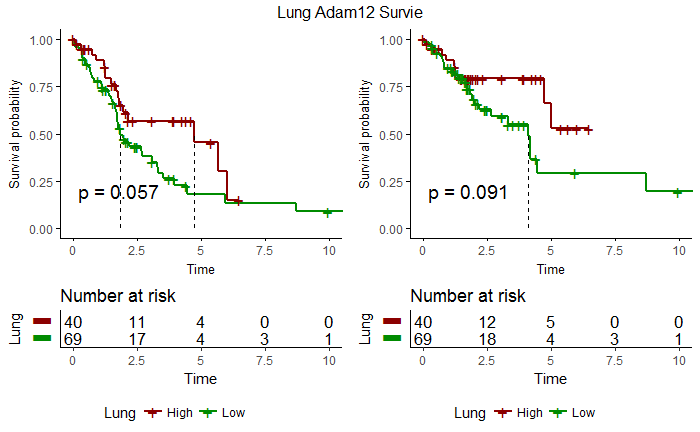

```r
fit_mort=survfit(Surv(time,status)~Decile,data=mydata2)
splots[[2]] <- ggsurvplot(fit_mort, data = mydata2,
   legend = "bottom",
   legend.title = "Lung",
  legend.labs = c("High", "Low"),
   palette = c("red4","green4"),
   font.x = c(10),
   font.y = c(10),
   main="Survie sans récidive",
   pval = TRUE,
              risk.table = TRUE,   surv.median.line=c("v"),
              tables.y.text = FALSE,
              ggtheme = theme_classic())

# Arrange multiple ggsurvplots and print the output
arrange_ggsurvplots(splots, print = TRUE, title="Lung Adam12 Survie",
  ncol = 2, nrow = 1, risk.table.height = 0.3)
```

## TESTS STATS

en changeant SIRT6 MAP3K7 KAT2A ADAM12

```r
summary(aov(ADAM12 ~ Quant2, data))
```

```r
#install.packages('PMCMRplus')
library(PMCMRplus)
#?tukeyTest

summary(tukeyTest(ADAM12 ~ Quant2, data))
```

#LUNG A²12 NT / Tum —————-

```r
coldata_lung=colData(rse_gene)

Type=rep(NA, length(clab_lung$Type))
Type[which(is.element(clab_lung$Type, c("Solid Tissue Normal"))==TRUE)]="Solid Tissue Normal"
Type[which(is.element(clab_lung$Type, c("Primary Tumor", "Metastatic"))==TRUE)]="Tumor"



ggplot(data=data.frame(stack(dds_tableTOT_lung[which(rownames(dds_tableTOT_lung)=="ADAM12"),]/median(ADAM_NT_lung)),
                       Type),
       aes(x=Type, y=log2(values), fill=Type))+
    geom_boxplot(position = position_dodge(0.9), notch=TRUE)+
  stat_summary(fun.y=mean, geom="point", shape=18,
                size=2, color="black",position = position_dodge(0.9))+
            geom_hline(yintercept=0, linetype="dashed", color = "grey")+
  labs(title="ADAM12 Lung", y="log2(FC) /SNT",x=" ",cex=10)+
  theme_classic()+
  theme(plot.title = element_text(size = 14, face = "bold",hjust=0.5),
              text=element_text(),
              axis.title = element_text(face="bold"),
              axis.text.x=element_text(angle=45, hjust=1,colour="black", size = 11),
              axis.text.y=element_text(colour="black", size = 9))+
  scale_x_discrete(limits=c("","Solid Tissue Normal","Tumor",""))+
  scale_fill_manual(values=c("white","black"))
```

## Stat

```r
library(ComplexHeatmap)
library(circlize)
#Pour le sein
lungsubADAM_TAK1_norm_tot=subADAM_TAK1_norm_tot[,which(as.data.frame(clab_ADAM_tot)$Tissue=="lung")]
for (i in c(1:dim(lungsubADAM_TAK1_norm_tot)[2])) {
  lungsubADAM_TAK1_norm_tot[which(lungsubADAM_TAK1_norm_tot[,i]==0),i]=NA
  lungsubADAM_TAK1_norm_tot[which(lungsubADAM_TAK1_norm_tot[,i]==Inf),i]=NA
   lungsubADAM_TAK1_norm_tot[which(is.nan(lungsubADAM_TAK1_norm_tot[,i])==T),i]=NA
}
lungsubADAM_TAK1_norm_tot=na.omit(lungsubADAM_TAK1_norm_tot)
which((lungsubADAM_TAK1_norm_tot)==0)
```

```
integer(0)
```

```r
Label_col=as.data.frame(as.data.frame(clab_ADAM_tot)$Decile[which(as.data.frame(clab_ADAM_tot)$Tissue=="lung")])
head(Label_col)
```

|  | as.data.frame(clab_ADAM_tot)$Decile[which(as.data.frame(clab_ADAM_tot)$Tissue == "lung")] |
| --- | --- |
| 1 | NT |
| 2 | NT |
| 3 | NT |
| 4 | NT |
| 5 | NT |
| 6 | NT |

```r
colnames(Label_col)="Decile"
levels(as.factor(Label_col$Decile))
```

```
[1] "NT"              "tumor_high_ADAM" "tumor_low_ADAM"
```

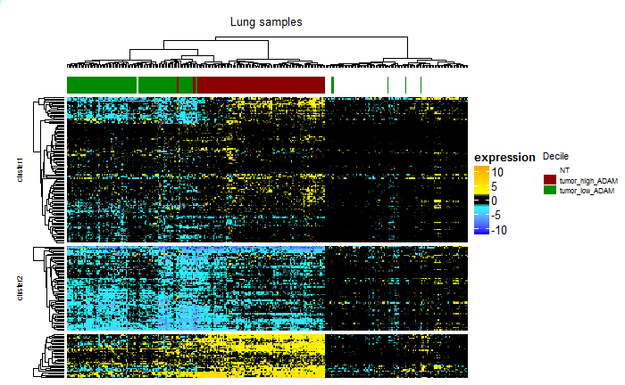

```r
Liste=list(Decile=c("NT"="white", "tumor_high_ADAM"="red4", "tumor_low_ADAM"="green4"))
ha= HeatmapAnnotation(df = Label_col,
                       col =  Liste,
                       annotation_legend_param = list(title_gp = gpar(fontsize = 8),
        labels_gp = gpar(fontsize = 6),grid_height = unit(3, "mm")),
        annotation_height =unit(0.5, "cm"))
Heatmap(as.matrix(log2(lungsubADAM_TAK1_norm_tot)),
   name="expression",
   cluster_columns = TRUE,
    clustering_distance_columns = "euclidean",
    clustering_method_columns = "ward.D2",
   column_title = "Lung samples", #titre
   column_title_gp = gpar(fontsize = 10),
    km = 3,
   row_title_gp = gpar(fontsize = c(6,6)),
    show_column_names = FALSE, #pas de nom des éch
    show_row_names = FALSE, #ni des gènes
    top_annotation = ha, #en top, les anno Cancer / NT etc
   top_annotation_height = unit(0.7, "cm"),
    show_heatmap_legend = TRUE,
  col = colorRamp2(c(-10,-2,-1, 0,1,2, 10), c("blue","cyan","black", "black","black","yellow", "orange"))
    #heatmap_legend_param = list(legend_direction = "vertical",
    #legend_width = unit(3, "cm"), title_position = "topcenter",fontsize = 6)
) #on ajoute les anno lignes
```

```r
summary(aov(values ~ Type,data))
```

```r
#install.packages('PMCMRplus')
library(PMCMRplus)
#?tukeyTest

summary(tukeyTest(values ~ Type,data))
```

## Courbe de survie selon expression ADAM12

```r
Type_sample=coldata_lung$gdc_cases.samples.sample_type

years_to_death=(coldata_lung$gdc_cases.diagnoses.days_to_death)/(365)
years_to_last_follow_up=coldata_lung$gdc_cases.diagnoses.days_to_last_follow_up/(365)
New_tumor_event=(coldata_lung$cgc_case_new_tumor_event_after_initial_treatment)

head(data.frame(years_to_death, years_to_last_follow_up, New_tumor_event))


#survie gloable : le premier évenement est la mort
Suivi_Mort=years_to_last_follow_up
Suivi_Mort[which(is.na(years_to_death)==FALSE)]=years_to_death[which(is.na(years_to_death)==FALSE)]

status_mort=rep(NA, length(years_to_death))
status_mort[which(is.na(years_to_death)==TRUE)]=0
status_mort[which(is.na(years_to_death)==FALSE)]=1

#survie sans progression : le premier évenement est la mort ou la rechute
Suivi_progression=years_to_last_follow_up
#on prend la date du dernier suivi, et si pas d'info on prend la date de la mort (généralement c'est exclusif)
Suivi_progression[which(is.na(years_to_last_follow_up)==TRUE)]=years_to_death[which(is.na(years_to_last_follow_up)==TRUE)]

status_recidive=rep(NA, length(New_tumor_event))
status_recidive[which(is.na(New_tumor_event)==TRUE)]=0
status_recidive[which(is.na(New_tumor_event)==FALSE)]=1 #on met des 1 si la personne rechute
status_recidive[which(is.na(years_to_death)==FALSE)]=1 #et des 1 si la personne récidive


head(cbind(Suivi_progression, status_recidive, Suivi_Mort, status_mort),10)
```

```r
library(survival)
library(survminer)

#summary(coldata_lung$xml_histological_type)
#Lung Squamous Cell Carcinoma- Not Otherwise Specified (NOS)
#Lung Adenocarcinoma- Not Otherwise Specified (NOS)
#Lung Adenocarcinoma Mixed Subtype

B="Lung Adenocarcinoma Mixed Subtype"

A=dds_tableTOT_lung[which(rownames(dds_tableTOT_lung)=="ADAM12"),]

Quant2=rep(NA, dim(dds_tableTOT_lung)[2])
Quant2[which(A>=quantile(A, na.rm=T, 0.5))]="High"
#Quant2[which(A<quantile(A, na.rm=T, 0.75))]="Int"
Quant2[which(A<=quantile(A, na.rm=T, 0.5))]="Low"

mydata=data.frame(time=Suivi_progression[which(Type_sample!="Solid Tissue Normal"&coldata_lung$xml_histological_type==B)],
                  status=status_recidive[which(Type_sample!="Solid Tissue Normal"&coldata_lung$xml_histological_type==B)],
                  Decile=Quant2[which(Type_sample!="Solid Tissue Normal"&coldata_lung$xml_histological_type==B)])

# List of ggsurvplots
splots <- list()

fit_recid=survfit(Surv(time,status)~Decile,data=mydata)

splots[[1]] <- ggsurvplot(fit_recid, data = mydata,
   legend = "bottom",
   legend.title = "Lung",
   legend.labs = c("High", "Low"),
   palette = c("red4", "green4"),
   font.x = c(10),
   font.y = c(10),
   main="Survie sans récidive",
   pval = TRUE,
              risk.table = TRUE,   surv.median.line=c("v"),
              tables.y.text = FALSE,
              ggtheme = theme_classic())

#2e plot = survie globale
mydata2=data.frame(time=Suivi_Mort[which(Type_sample!="Solid Tissue Normal"&coldata_lung$xml_histological_type==B)],
                  status=status_mort[which(Type_sample!="Solid Tissue Normal"&coldata_lung$xml_histological_type==B)],
                  Decile=Quant2[which(Type_sample!="Solid Tissue Normal"&coldata_lung$xml_histological_type==B)])
summary(as.factor(mydata$status))

fit_mort=survfit(Surv(time,status)~Decile,data=mydata2)

splots[[2]] <- ggsurvplot(fit_mort, data = mydata2,
   legend = "bottom",
   legend.title = "Lung",
  legend.labs = c("High", "Low"),
   palette = c("red4","green4"),
   font.x = c(10),
   font.y = c(10),
   main="Survie sans récidive",
   pval = TRUE,
              risk.table = TRUE,   surv.median.line=c("v"),
              tables.y.text = FALSE,
              ggtheme = theme_classic())

# Arrange multiple ggsurvplots and print the output
arrange_ggsurvplots(splots, print = TRUE, title="Lung Adam12 Survie",
  ncol = 2, nrow = 1, risk.table.height = 0.3)
```

## Heatmap

```r
library(ComplexHeatmap)
library(circlize)
#Pour le sein

lungsubADAM_TAK1_norm_tot=subADAM_TAK1_norm_tot[,which(as.data.frame(clab_ADAM_tot)$Tissue=="lung")]

for (i in c(1:dim(lungsubADAM_TAK1_norm_tot)[2])) {
  lungsubADAM_TAK1_norm_tot[which(lungsubADAM_TAK1_norm_tot[,i]==0),i]=NA
  lungsubADAM_TAK1_norm_tot[which(lungsubADAM_TAK1_norm_tot[,i]==Inf),i]=NA
   lungsubADAM_TAK1_norm_tot[which(is.nan(lungsubADAM_TAK1_norm_tot[,i])==T),i]=NA
}

lungsubADAM_TAK1_norm_tot=na.omit(lungsubADAM_TAK1_norm_tot)
which((lungsubADAM_TAK1_norm_tot)==0)

Label_col=as.data.frame(as.data.frame(clab_ADAM_tot)$Decile[which(as.data.frame(clab_ADAM_tot)$Tissue=="lung")])
head(Label_col)
colnames(Label_col)="Decile"
levels(as.factor(Label_col$Decile))

Liste=list(Decile=c("NT"="white", "tumor_high_ADAM"="red4", "tumor_low_ADAM"="green4"))

ha= HeatmapAnnotation(df = Label_col,
                       col =  Liste,
                       annotation_legend_param = list(title_gp = gpar(fontsize = 8),
        labels_gp = gpar(fontsize = 6),grid_height = unit(3, "mm")),
        annotation_height =unit(0.5, "cm"))

Heatmap(as.matrix(log2(lungsubADAM_TAK1_norm_tot)),
   name="expression",
   cluster_columns = TRUE,
    clustering_distance_columns = "euclidean",
    clustering_method_columns = "ward.D2",
   column_title = "Lung samples", #titre
   column_title_gp = gpar(fontsize = 10),
    km = 3,
   row_title_gp = gpar(fontsize = c(6,6)),
    show_column_names = FALSE, #pas de nom des éch
    show_row_names = FALSE, #ni des gènes
    top_annotation = ha, #en top, les anno Cancer / NT etc
   top_annotation_height = unit(0.7, "cm"),
    show_heatmap_legend = TRUE,
  col = colorRamp2(c(-10,-2,-1, 0,1,2, 10), c("blue","cyan","black", "black","black","yellow", "orange"))
    #heatmap_legend_param = list(legend_direction = "vertical",
    #legend_width = unit(3, "cm"), title_position = "topcenter",fontsize = 6)
) #on ajoute les anno lignes
```

## Corrélation

```r
A=dds_tableTOT_lung[which(rownames(dds_tableTOT_lung)=="ADAM12"),]

Type=rep("Int", dim(dds_tableTOT_lung)[2])
Type[which(A>=quantile(A, na.rm=T, 0.9))]="High"
Type[which(A<=quantile(A, na.rm=T, 0.1))]="Low"
Type[which(is.element(clab_lung$Type, c("Solid Tissue Normal"))==TRUE)]=NA
Type=as.factor(Type)


#on enlève les valeurs normales

Tak1_all=apply(dds_tableTOT_lung[which(is.element(rownames(dds_tableTOT_lung), SignatureTAK1$V1)==TRUE),],
               2,
               sum)

Adam=dds_tableTOT_lung[which(rownames(dds_tableTOT_lung)=="ADAM12"),]


#Score TAK1 par colonne

data=data.frame(Tak=Tak1_all,
           Adam=t(Adam),
           Type=Type)
colnames(data)=c("Tak","Adam", "Type")
head(data)

#Coeff de corrélation
xm = as.matrix(log2(data[,1:2]+1))
#head(xm[,])
library("Hmisc")

M <-  rcorr(xm, type = "pearson")
M
library(ggplot2)
ggplot(data=data, aes(x=log2(1+Adam), y=log2(1+Tak), color=Type))+
  geom_point()+
  geom_smooth(colour = "black",fill="white", method = "lm") +
  scale_color_manual(values=c("red4", "black","green4"))+
  labs(title="Correlation ADAM12 & TAK1 activation \n All Tumors", y="TAK1 activation Score",x="log2(ADAM12 expression)",cex=10)+
  theme_classic()+
 theme(plot.title = element_text(size = 14, face = "bold",hjust = 0.5),
              text=element_text(),
              axis.title = element_text(face="bold"),
              axis.text.x=element_text(angle=45, hjust=1,colour="black", size = 11),
              axis.text.y=element_text(colour="black", size = 9))+
      annotate("text", x = 15.05, y = 23.05, label = equation(M), parse = TRUE)
```

## Boxplot

```r
ggplot(subADAM_tot[which(is.element(subADAM_tot$Gene,c("ADAM12"))==TRUE),],
       aes(x=Type, y=log2(values), fill=Decile))+
    geom_boxplot(position = position_dodge(0.9), notch=TRUE)+
  stat_summary(fun.y=mean, geom="point", shape=18,
                size=4, color="black",position = position_dodge(0.9))+
            geom_hline(yintercept=0, linetype="dashed", color = "grey10")+
  labs(title="ADAM12", y="log2(FC)",x=" ",cex=10)+
  theme_classic()+
  theme(plot.title = element_text(size = 14, face = "bold",hjust=0.5),
              text=element_text(),
              axis.title = element_text(face="bold"),
              axis.text.x=element_text(angle=45, hjust=1,colour="black", size = 11),
              axis.text.y=element_text(colour="black", size = 9))+
 scale_fill_manual(values=c("white","red4","green4"))+
  scale_x_discrete(limits=c(
   #"COAD",
   "","LUNG",""
    #"","BREAST",""
   ))
```

```r
ggplot(subADAM_tot[which(is.element(subADAM_tot$Gene,c("MAP3K7"))==TRUE),],
       aes(x=Type, y=log2(values), fill=Decile))+
    geom_boxplot(position = position_dodge(0.9), notch=TRUE)+
  stat_summary(fun.y=mean, geom="point", shape=18,
                size=4, color="black",position = position_dodge(0.9))+
            geom_hline(yintercept=0, linetype="dashed", color = "grey10")+
  labs(title="TAK1", y="log2(FC)",x=" ",cex=10)+
  theme_classic()+
  theme(plot.title = element_text(size = 14, face = "bold",hjust=0.5),
              text=element_text(),
              axis.title = element_text(face="bold"),
              axis.text.x=element_text(angle=45, hjust=1,colour="black", size = 11),
              axis.text.y=element_text(colour="black", size = 9))+
 scale_fill_manual(values=c("white","red4","green4"))+
  scale_x_discrete(limits=c(
   #"COAD",
   "","LUNG",""
    #"","BREAST",""
   ))
```

```r
ggplot(subADAM_tot[which(is.element(subADAM_tot$Gene,c("KAT2A"))==TRUE),],
       aes(x=Type, y=log2(values), fill=Decile))+
    geom_boxplot(position = position_dodge(0.9), notch=TRUE)+
  stat_summary(fun.y=mean, geom="point", shape=18,
                size=4, color="black",position = position_dodge(0.9))+
            geom_hline(yintercept=0, linetype="dashed", color = "grey10")+
  labs(title="KAT2A", y="log2(FC)",x=" ",cex=10)+
  theme_classic()+
  theme(plot.title = element_text(size = 14, face = "bold",hjust=0.5),
              text=element_text(),
              axis.title = element_text(face="bold"),
              axis.text.x=element_text(angle=45, hjust=1,colour="black", size = 11),
              axis.text.y=element_text(colour="black", size = 9))+
 scale_fill_manual(values=c("white","red4","green4"))+
  scale_x_discrete(limits=c(
   #"COAD",
   "","LUNG",""
    #"","BREAST",""
   ))
```

```r
ggplot(subADAM_tot[which(is.element(subADAM_tot$Gene,c("SIRT6"))==TRUE),],
       aes(x=Type, y=log2(values), fill=Decile))+
    geom_boxplot(position = position_dodge(0.9), notch=TRUE)+
  stat_summary(fun.y=mean, geom="point", shape=18,
                size=4, color="black",position = position_dodge(0.9))+
            geom_hline(yintercept=0, linetype="dashed", color = "grey10")+
  labs(title="SIRT6", y="log2(FC)",x=" ",cex=10)+
  theme_classic()+
  theme(plot.title = element_text(size = 14, face = "bold",hjust=0.5),
              text=element_text(),
              axis.title = element_text(face="bold"),
              axis.text.x=element_text(angle=45, hjust=1,colour="black", size = 11),
              axis.text.y=element_text(colour="black", size = 9))+
 scale_fill_manual(values=c("white","red4","green4"))+
  scale_x_discrete(limits=c(
   #"COAD",
   "","LUNG",""
    #"","BREAST",""
   ))
```

## TESTS STATS

en changeant SIRT6 MAP3K7 KAT2A ADAM12

```r
summary(aov(values ~ Decile, subset(subset(subADAM_tot, Gene %in% "MAP3K7"),
              Type %in% "LUNG")))
```

```r
#install.packages('PMCMRplus')
library(PMCMRplus)
#?tukeyTest

summary(tukeyTest(values ~ Decile, subset(subset(subADAM_tot, Gene %in% "MAP3K7"),
              Type %in% "LUNG")))
```

#COAD A²12 NT / Tum —————-

```r
#coldata_lung=colData(rse_gene)

Type=rep(NA, length(clab_CRC$Type))
Type[which(is.element(clab_CRC$Type, c("hotpink"))==TRUE)]="Solid Tissue Normal"
Type[which(is.element(clab_CRC$Type, c("black", "grey50"))==TRUE)]="Tumor"



ggplot(data=data.frame(stack(dds_tableTOT_CRC[which(rownames(dds_tableTOT_CRC)=="ADAM12"),]/median(ADAM_NT_CRC)),
                       Type),
       aes(x=Type, y=log2(values), fill=Type))+
    geom_boxplot(position = position_dodge(0.9), notch=TRUE)+
  stat_summary(fun.y=mean, geom="point", shape=18,
                size=2, color="black",position = position_dodge(0.9))+
            geom_hline(yintercept=0, linetype="dashed", color = "grey")+
  labs(title="ADAM12 Coad", y="log2(FC) /SNT",x=" ",cex=10)+
  theme_classic()+
  theme(plot.title = element_text(size = 14, face = "bold",hjust=0.5),
              text=element_text(),
              axis.title = element_text(face="bold"),
              axis.text.x=element_text(angle=45, hjust=1,colour="black", size = 11),
              axis.text.y=element_text(colour="black", size = 9))+
  scale_x_discrete(limits=c("","Solid Tissue Normal","Tumor",""))+
  scale_fill_manual(values=c("white","black"))
```

## Stat

```r
library(ComplexHeatmap)
library(circlize)
#Pour le sein
crcsubADAM_TAK1_norm_tot=subADAM_TAK1_norm_tot[,which(as.data.frame(clab_ADAM_tot)$Tissue=="CRC")]
for (i in c(1:dim(crcsubADAM_TAK1_norm_tot)[2])) {
  crcsubADAM_TAK1_norm_tot[which(crcsubADAM_TAK1_norm_tot[,i]==0),i]=NA
  crcsubADAM_TAK1_norm_tot[which(crcsubADAM_TAK1_norm_tot[,i]==Inf),i]=NA
   crcsubADAM_TAK1_norm_tot[which(is.nan(crcsubADAM_TAK1_norm_tot[,i])==T),i]=NA
}
crcsubADAM_TAK1_norm_tot=na.omit(crcsubADAM_TAK1_norm_tot)
which((crcsubADAM_TAK1_norm_tot)==0)
```

```
integer(0)
```

```r
Label_col=as.data.frame(as.data.frame(clab_ADAM_tot)$Decile[which(as.data.frame(clab_ADAM_tot)$Tissue=="CRC")])
head(Label_col)
```

|  | as.data.frame(clab_ADAM_tot)$Decile[which(as.data.frame(clab_ADAM_tot)$Tissue == "CRC")] |
| --- | --- |
| 1 | NT |
| 2 | NT |
| 3 | NT |
| 4 | NT |
| 5 | NT |
| 6 | NT |

```r
colnames(Label_col)="Decile"
levels(as.factor(Label_col$Decile))
```

```
[1] "NT"              "tumor_high_ADAM" "tumor_low_ADAM"
```

```r
Liste=list(Decile=c("NT"="white", "tumor_high_ADAM"="red4", "tumor_low_ADAM"="green4"))
ha= HeatmapAnnotation(df = Label_col,
                       col =  Liste,
                       annotation_legend_param = list(title_gp = gpar(fontsize = 8),
        labels_gp = gpar(fontsize = 6),grid_height = unit(3, "mm")),
        annotation_height =unit(0.5, "cm"))
Heatmap(as.matrix(log2(crcsubADAM_TAK1_norm_tot)),
   name="expression",
   cluster_columns = TRUE,
    clustering_distance_columns = "euclidean",
    clustering_method_columns = "ward.D2",
   column_title = "Lung samples", #titre
   column_title_gp = gpar(fontsize = 10),
    km = 3,
   row_title_gp = gpar(fontsize = c(6,6)),
    show_column_names = FALSE, #pas de nom des éch
    show_row_names = FALSE, #ni des gènes
    top_annotation = ha, #en top, les anno Cancer / NT etc
   top_annotation_height = unit(0.7, "cm"),
    show_heatmap_legend = TRUE,
  col = colorRamp2(c(-10,-2,-1, 0,1,2, 10), c("blue","cyan","black", "black","black","yellow", "orange"))
    #heatmap_legend_param = list(legend_direction = "vertical",
    #legend_width = unit(3, "cm"), title_position = "topcenter",fontsize = 6)
) #on ajoute les anno lignes
```

```r
summary(aov(values ~ Type,data))
```

```r
#install.packages('PMCMRplus')
library(PMCMRplus)
#?tukeyTest

summary(tukeyTest(values ~ Type,data))
```

## Courbe de survie selon expression ADAM12

```r
Type_sample=coldata_lung$gdc_cases.samples.sample_type

years_to_death=(coldata_lung$gdc_cases.diagnoses.days_to_death)/(365)
years_to_last_follow_up=coldata_lung$gdc_cases.diagnoses.days_to_last_follow_up/(365)
New_tumor_event=(coldata_lung$cgc_case_new_tumor_event_after_initial_treatment)

head(data.frame(years_to_death, years_to_last_follow_up, New_tumor_event))


#survie gloable : le premier évenement est la mort
Suivi_Mort=years_to_last_follow_up
Suivi_Mort[which(is.na(years_to_death)==FALSE)]=years_to_death[which(is.na(years_to_death)==FALSE)]

status_mort=rep(NA, length(years_to_death))
status_mort[which(is.na(years_to_death)==TRUE)]=0
status_mort[which(is.na(years_to_death)==FALSE)]=1

#survie sans progression : le premier évenement est la mort ou la rechute
Suivi_progression=years_to_last_follow_up
#on prend la date du dernier suivi, et si pas d'info on prend la date de la mort (généralement c'est exclusif)
Suivi_progression[which(is.na(years_to_last_follow_up)==TRUE)]=years_to_death[which(is.na(years_to_last_follow_up)==TRUE)]

status_recidive=rep(NA, length(New_tumor_event))
status_recidive[which(is.na(New_tumor_event)==TRUE)]=0
status_recidive[which(is.na(New_tumor_event)==FALSE)]=1 #on met des 1 si la personne rechute
status_recidive[which(is.na(years_to_death)==FALSE)]=1 #et des 1 si la personne récidive


head(cbind(Suivi_progression, status_recidive, Suivi_Mort, status_mort),10)
```

```r
library(survival)
library(survminer)

#summary(coldata_lung$xml_histological_type)
#Lung Squamous Cell Carcinoma- Not Otherwise Specified (NOS)
#Lung Adenocarcinoma- Not Otherwise Specified (NOS)
#Lung Adenocarcinoma Mixed Subtype

B="Lung Adenocarcinoma Mixed Subtype"

A=dds_tableTOT_lung[which(rownames(dds_tableTOT_lung)=="ADAM12"),]

Quant2=rep(NA, dim(dds_tableTOT_lung)[2])
Quant2[which(A>=quantile(A, na.rm=T, 0.5))]="High"
#Quant2[which(A<quantile(A, na.rm=T, 0.75))]="Int"
Quant2[which(A<=quantile(A, na.rm=T, 0.5))]="Low"

mydata=data.frame(time=Suivi_progression[which(Type_sample!="Solid Tissue Normal"&coldata_lung$xml_histological_type==B)],
                  status=status_recidive[which(Type_sample!="Solid Tissue Normal"&coldata_lung$xml_histological_type==B)],
                  Decile=Quant2[which(Type_sample!="Solid Tissue Normal"&coldata_lung$xml_histological_type==B)])

# List of ggsurvplots
splots <- list()

fit_recid=survfit(Surv(time,status)~Decile,data=mydata)

splots[[1]] <- ggsurvplot(fit_recid, data = mydata,
   legend = "bottom",
   legend.title = "Lung",
   legend.labs = c("High", "Low"),
   palette = c("red4", "green4"),
   font.x = c(10),
   font.y = c(10),
   main="Survie sans récidive",
   pval = TRUE,
              risk.table = TRUE,   surv.median.line=c("v"),
              tables.y.text = FALSE,
              ggtheme = theme_classic())

#2e plot = survie globale
mydata2=data.frame(time=Suivi_Mort[which(Type_sample!="Solid Tissue Normal"&coldata_lung$xml_histological_type==B)],
                  status=status_mort[which(Type_sample!="Solid Tissue Normal"&coldata_lung$xml_histological_type==B)],
                  Decile=Quant2[which(Type_sample!="Solid Tissue Normal"&coldata_lung$xml_histological_type==B)])
summary(as.factor(mydata$status))

fit_mort=survfit(Surv(time,status)~Decile,data=mydata2)

splots[[2]] <- ggsurvplot(fit_mort, data = mydata2,
   legend = "bottom",
   legend.title = "Lung",
  legend.labs = c("High", "Low"),
   palette = c("red4","green4"),
   font.x = c(10),
   font.y = c(10),
   main="Survie sans récidive",
   pval = TRUE,
              risk.table = TRUE,   surv.median.line=c("v"),
              tables.y.text = FALSE,
              ggtheme = theme_classic())

# Arrange multiple ggsurvplots and print the output
arrange_ggsurvplots(splots, print = TRUE, title="Lung Adam12 Survie",
  ncol = 2, nrow = 1, risk.table.height = 0.3)
```

## Heatmap

```r
library(ComplexHeatmap)
library(circlize)
#Pour le sein

crcsubADAM_TAK1_norm_tot=subADAM_TAK1_norm_tot[,which(as.data.frame(clab_ADAM_tot)$Tissue=="CRC")]

for (i in c(1:dim(crcsubADAM_TAK1_norm_tot)[2])) {
  crcsubADAM_TAK1_norm_tot[which(crcsubADAM_TAK1_norm_tot[,i]==0),i]=NA
  crcsubADAM_TAK1_norm_tot[which(crcsubADAM_TAK1_norm_tot[,i]==Inf),i]=NA
   crcsubADAM_TAK1_norm_tot[which(is.nan(crcsubADAM_TAK1_norm_tot[,i])==T),i]=NA
}

crcsubADAM_TAK1_norm_tot=na.omit(crcsubADAM_TAK1_norm_tot)
which((crcsubADAM_TAK1_norm_tot)==0)

Label_col=as.data.frame(as.data.frame(clab_ADAM_tot)$Decile[which(as.data.frame(clab_ADAM_tot)$Tissue=="CRC")])
head(Label_col)
colnames(Label_col)="Decile"
levels(as.factor(Label_col$Decile))

Liste=list(Decile=c("NT"="white", "tumor_high_ADAM"="red4", "tumor_low_ADAM"="green4"))

ha= HeatmapAnnotation(df = Label_col,
                       col =  Liste,
                       annotation_legend_param = list(title_gp = gpar(fontsize = 8),
        labels_gp = gpar(fontsize = 6),grid_height = unit(3, "mm")),
        annotation_height =unit(0.5, "cm"))

Heatmap(as.matrix(log2(crcsubADAM_TAK1_norm_tot)),
   name="expression",
   cluster_columns = TRUE,
    clustering_distance_columns = "euclidean",
    clustering_method_columns = "ward.D2",
   column_title = "Lung samples", #titre
   column_title_gp = gpar(fontsize = 10),
    km = 3,
   row_title_gp = gpar(fontsize = c(6,6)),
    show_column_names = FALSE, #pas de nom des éch
    show_row_names = FALSE, #ni des gènes
    top_annotation = ha, #en top, les anno Cancer / NT etc
   top_annotation_height = unit(0.7, "cm"),
    show_heatmap_legend = TRUE,
  col = colorRamp2(c(-10,-2,-1, 0,1,2, 10), c("blue","cyan","black", "black","black","yellow", "orange"))
    #heatmap_legend_param = list(legend_direction = "vertical",
    #legend_width = unit(3, "cm"), title_position = "topcenter",fontsize = 6)
) #on ajoute les anno lignes
```

## Correlation

```r
A=dds_tableTOT_CRC[which(rownames(dds_tableTOT_CRC)=="ADAM12"),]

Type=rep("Int", dim(dds_tableTOT_CRC)[2])
Type[which(A>=quantile(A, na.rm=T, 0.9))]="High"
Type[which(A<=quantile(A, na.rm=T, 0.1))]="Low"
Type[which(is.element(clab_CRC$Type, c("Solid Tissue Normal"))==TRUE)]=NA
Type=as.factor(Type)


#on enlève les valeurs normales

Tak1_all=apply(dds_tableTOT_CRC[which(is.element(rownames(dds_tableTOT_CRC), SignatureTAK1$V1)==TRUE),],
               2,
               sum)

Adam=dds_tableTOT_CRC[which(rownames(dds_tableTOT_CRC)=="ADAM12"),]


#Score TAK1 par colonne

data=data.frame(Tak=Tak1_all,
           Adam=t(Adam),
           Type=Type)
colnames(data)=c("Tak","Adam", "Type")
head(data)

#Coeff de corrélation
xm = as.matrix(log2(data[,1:2]+1))
#head(xm[,])
library("Hmisc")

M <-  rcorr(xm, type = "pearson")
M
library(ggplot2)

ggplot(data=data, aes(x=log2(1+Adam), y=log2(1+Tak), color=Type))+
  geom_point()+
  geom_smooth(colour = "black",fill="white", method = "lm") +
  scale_color_manual(values=c("red4", "black","green4"))+
  labs(title="Correlation ADAM12 & TAK1 activation \n All Tumors", y="TAK1 activation Score",x="log2(ADAM12 expression)",cex=10)+
  theme_classic()+
 theme(plot.title = element_text(size = 14, face = "bold",hjust = 0.5),
              text=element_text(),
              axis.title = element_text(face="bold"),
              axis.text.x=element_text(angle=45, hjust=1,colour="black", size = 11),
              axis.text.y=element_text(colour="black", size = 9))+
      annotate("text", x = 15.05, y = 23.05, label = equation(M), parse = TRUE)
```

## Boxplot

```r
ggplot(subADAM_tot[which(is.element(subADAM_tot$Gene,c("ADAM12"))==TRUE),],
       aes(x=Type, y=log2(values), fill=Decile))+
    geom_boxplot(position = position_dodge(0.9), notch=TRUE)+
  stat_summary(fun.y=mean, geom="point", shape=18,
                size=4, color="black",position = position_dodge(0.9))+
            geom_hline(yintercept=0, linetype="dashed", color = "grey10")+
  labs(title="ADAM12", y="log2(FC)",x=" ",cex=10)+
  theme_classic()+
  theme(plot.title = element_text(size = 14, face = "bold",hjust=0.5),
              text=element_text(),
              axis.title = element_text(face="bold"),
              axis.text.x=element_text(angle=45, hjust=1,colour="black", size = 11),
              axis.text.y=element_text(colour="black", size = 9))+
 scale_fill_manual(values=c("white","red4","green4"))+
  scale_x_discrete(limits=c(
   " ","COAD"," "
  # "","LUNG",""
    #"","BREAST",""
   ))
```

```r
ggplot(subADAM_tot[which(is.element(subADAM_tot$Gene,c("MAP3K7"))==TRUE),],
       aes(x=Type, y=log2(values), fill=Decile))+
    geom_boxplot(position = position_dodge(0.9), notch=TRUE)+
  stat_summary(fun.y=mean, geom="point", shape=18,
                size=4, color="black",position = position_dodge(0.9))+
            geom_hline(yintercept=0, linetype="dashed", color = "grey10")+
  labs(title="TAK1", y="log2(FC)",x=" ",cex=10)+
  theme_classic()+
  theme(plot.title = element_text(size = 14, face = "bold",hjust=0.5),
              text=element_text(),
              axis.title = element_text(face="bold"),
              axis.text.x=element_text(angle=45, hjust=1,colour="black", size = 11),
              axis.text.y=element_text(colour="black", size = 9))+
 scale_fill_manual(values=c("white","red4","green4"))+
  scale_x_discrete(limits=c(
   " ","COAD"," "
  # "","LUNG",""
    #"","BREAST",""
   ))
```

```r
ggplot(subADAM_tot[which(is.element(subADAM_tot$Gene,c("KAT2A"))==TRUE),],
       aes(x=Type, y=log2(values), fill=Decile))+
    geom_boxplot(position = position_dodge(0.9), notch=TRUE)+
  stat_summary(fun.y=mean, geom="point", shape=18,
                size=4, color="black",position = position_dodge(0.9))+
            geom_hline(yintercept=0, linetype="dashed", color = "grey10")+
  labs(title="KAT2A", y="log2(FC)",x=" ",cex=10)+
  theme_classic()+
  theme(plot.title = element_text(size = 14, face = "bold",hjust=0.5),
              text=element_text(),
              axis.title = element_text(face="bold"),
              axis.text.x=element_text(angle=45, hjust=1,colour="black", size = 11),
              axis.text.y=element_text(colour="black", size = 9))+
 scale_fill_manual(values=c("white","red4","green4"))+
  scale_x_discrete(limits=c(
   " ","COAD"," "
  # "","LUNG",""
    #"","BREAST",""
   ))
```

```r
ggplot(subADAM_tot[which(is.element(subADAM_tot$Gene,c("SIRT6"))==TRUE),],
       aes(x=Type, y=log2(values), fill=Decile))+
    geom_boxplot(position = position_dodge(0.9), notch=TRUE)+
  stat_summary(fun.y=mean, geom="point", shape=18,
                size=4, color="black",position = position_dodge(0.9))+
            geom_hline(yintercept=0, linetype="dashed", color = "grey10")+
  labs(title="SIRT6", y="log2(FC)",x=" ",cex=10)+
  theme_classic()+
  theme(plot.title = element_text(size = 14, face = "bold",hjust=0.5),
              text=element_text(),
              axis.title = element_text(face="bold"),
              axis.text.x=element_text(angle=45, hjust=1,colour="black", size = 11),
              axis.text.y=element_text(colour="black", size = 9))+
 scale_fill_manual(values=c("white","red4","green4"))+
  scale_x_discrete(limits=c(
   " ","COAD"," "
  # "","LUNG",""
    #"","BREAST",""
   ))
```

## TESTS STATS

en changeant SIRT6 MAP3K7 KAT2A ADAM12

```r
summary(aov(values ~ Decile, subset(subset(subADAM_tot, Gene %in% "ADAM12"),
              Type %in% "COAD")))
```

```r
#install.packages('PMCMRplus')
library(PMCMRplus)
#?tukeyTest

summary(tukeyTest(values ~ Decile, subset(subset(subADAM_tot, Gene %in% "ADAM12"),
              Type %in% "COAD")))
```